# RNA-Seq Transcriptome Basic Data Analysis: RNA Preprocessing

sho

2020 8 7

# I. Introduction

In this exercise, we use TopHat, Cufflinks, HiSAT2, StringTie and these softwares depend on Bowtie, SAMtools, etc. Also we use DEGseq R package for gene expression analysis. [Article from Incodom about DEGseq](http://www.incodom.kr/R_%28%ED%94%84%EB%A1%9C%EA%B7%B8%EB%9E%98%EB%B0%8D_%EC%96%B8%EC%96%B4%29/Bioconductor/DEGseq)

```r
library(DEGseq)
getwd()
```

```
## [1] "/home/seungho/GDA/RNAPreprocess"
```

```r
dir()
```

```
##  [1] "188462_1.Fastq"                "188462_2.Fastq"
##  [3] "188467_1.Fastq"                "188467_2.Fastq"
##  [5] "assemblies.txt"                "ballgown"
##  [7] "ballgown_188462"               "ballgown_188467"
##  [9] "cuff_out"                      "cufflinks_188462"
## [11] "cufflinks_188467"              "DE_pipeline_refonly.png"
## [13] "DE_pipeline.png"               "DEGexpExample"
## [15] "degseq_report_page.jpeg"       "final_problem.png"
## [17] "fourteen_samples_DEG_analysis" "gffcompare.gif"
## [19] "hisat2_188462"                 "hisat2_188467"
## [21] "merged_asm"                    "mergelists.txt"
## [23] "name-diff_out"                 "new_tuxedo.png"
## [25] "output"                        "phenodata.csv"
## [27] "rna_preprocess.html"           "rna_preprocess.Rmd"
## [29] "SampleGenes.gtf"               "SampleReference.1.bt2"
## [31] "SampleReference.1.ebwt"        "SampleReference.2.bt2"
## [33] "SampleReference.2.ebwt"        "SampleReference.3.bt2"
## [35] "SampleReference.3.ebwt"        "SampleReference.4.bt2"
## [37] "SampleReference.4.ebwt"        "SampleReference.fa"
## [39] "SampleReference.fa.fai"        "SampleReference.rev.1.bt2"
## [41] "SampleReference.rev.1.ebwt"    "SampleReference.rev.2.bt2"
## [43] "SampleReference.rev.2.ebwt"    "skittles.png"
## [45] "stringtie_188462"              "stringtie_188467"
## [47] "TCGA_BRCA_Sample.txt"          "tmp.XXvjfUdD"
## [49] "tools"                         "tophat_188462"
## [51] "tophat_188467"                 "tophat_out"
## [53] "Tophat_pipeline.png"           "tuxedo_overview.png"
```

```
[soh1@x020 RNAPreprocess]$ ls
188462_1.Fastq          SampleReference.3.bt2       SampleReference.rev.2.ebwt  hisat2_188462     tmp.XXvjfUdD
188462_2.Fastq          SampleReference.3.ebwt      TCGA_BRCA_Sample.txt        hisat2_188467     tools
188467_1.Fastq          SampleReference.4.bt2       assemblies.txt              merged_asm        tophat_188462
188467_2.Fastq          SampleReference.4.ebwt      ballgown                    mergelists.txt    tophat_188467
SampleGenes.gtf         SampleReference.fa          ballgown_188462             name-diff_out     tophat_out
SampleReference.1.bt2   SampleReference.fa.fai      ballgown_188467             output
SampleReference.1.ebwt  SampleReference.rev.1.bt2   cuff_out                    phenodata.csv
SampleReference.2.bt2   SampleReference.rev.1.ebwt  cufflinks_188462            stringtie_188462
SampleReference.2.ebwt  SampleReference.rev.2.bt2   cufflinks_188467            stringtie_188467
```

## RNA-Seq data

This is what `SampleGenes.gtf` looks like.

```
chr1    unknown exon    323892  324060  .       +       .       gene_id "LOC100133331"; gene_name "LOC100133331"; transcript_id "NR_028327_1"; tss_id "TSS11868";
chr1    unknown exon    324288  324345  .       +       .       gene_id "LOC100132287"; gene_name "LOC100132287"; transcript_id "NR_028322"; tss_id "TSS11868";
chr1    unknown exon    324288  324345  .       +       .       gene_id "LOC100132062"; gene_name "LOC100132062"; transcript_id "NR_028325"; tss_id "TSS11868";
chr1    unknown exon    324288  324345  .       +       .       gene_id "LOC100133331"; gene_name "LOC100133331"; transcript_id "NR_028327_1"; tss_id "TSS11868";
chr1    unknown exon    324439  326938  .       +       .       gene_id "LOC100133331"; gene_name "LOC100133331"; transcript_id "NR_028327_1"; tss_id "TSS11868";
chr1    unknown exon    324439  328581  .       +       .       gene_id "LOC100132287"; gene_name "LOC100132287"; transcript_id "NR_028322"; tss_id "TSS11868";
chr1    unknown exon    324439  328581  .       +       .       gene_id "LOC100132062"; gene_name "LOC100132062"; transcript_id "NR_028325"; tss_id "TSS11868";
```

`.fastq` files are unaligned raw data of RNA-Seq reads with quality scores.

```
@ERR188462.9643448/1
TGGCAATCTCGTTTAAACTACATGCAGGAACAGCAAAGGAAATCCGGCAAATTTGCGCAGTCATTCTCAACACCG
+
@@@ADDDDDHD:ACEHH@HBCEECHIIDGI?FACHHEHGGGFGGIIBGHIGGGEHIIIDHEEEEEEDCDCCCCBB
```

1. TopHat: TopHat is the tool to be used in short read alignnment. It uses Bowtie engine to map reads the reference genome. In Bowtie, FM-indexing with backtracking has been successfully applied to approximate string matching/sequence alignment. Refer to this [page](http://bowtie-bio.sourceforge.net/index.shtml). In compouter science, FM-index is a compressed full-text substring index based on the Burrows-Wheeler transform, with some similarities to the suffix array. It was created by paolo Ferragina and Giovanni Manzini, who describe it as an opportunistic data structrue as it allows compression of the input text while permitting fast substring queries. The names stands for Full-text index in Minute space. So an FM-index is created by first taking the Burrows-Wheeler transform (BWT) of the input text. For example, the BWT of the string T= “abracadabra$” is “ard$rcaaaabb”, and here it is represented by the matrix $\textrm{M}$ where each row is a rotation of the text, and the rows have been sorted lexicographicallyl. The transform corresponds to the last column labeled L.

| I | F |  | L |
| --- | --- | --- | --- |
| 1 | $ | abracadabr | a |
| 2 | a | $abracadab | r |
| 3 | a | bra$abraca | d |
| 4 | a | bracadabra | $ |
| 5 | a | cadabra$ab | r |
| 6 | a | dabra$abra | c |
| 7 | b | ra$abracad | a |
| 8 | b | racadabra$ | a |
| 9 | c | adabra$abr | a |
| 10 | d | abra$abrac | a |
| 11 | r | a$abracada | b |
| 12 | r | acadabra$a | b |

The BWT in itself allows for some compresesion with, for instance, move to front and Huffman encoding, but the transform has even more uses. The rows in the matrix are essentially the sorted suffixes of the text and the first column F of the matrix shares similarities with suffix arrays. How the suffix array relates to the BWT lies at the heart of the FM-index. It is possible to make a last-to-first column mapping $\textrm{LF(i)}$ from an index $i$ to an index $j$, such that $\textrm{F[j] = L[i]}$, with the help of a table $\textrm{C[c]}$ and a function $\textrm{Occ(c,k)}$. $\textrm{C[c]}$ constains the number of occurrences of lexically smaller characters in the text. (number of occurrence). $\textrm{Occ(c,k)}$ is the number of occurrences of character $\textrm{c}$ in the prefix $\textrm{L[1..k]}$. (number of occurrences of the character up until that point.) Last-to-first mapping can be defined as $\textrm{LF(i) = C[L[i]] + Occ(L[i],i)}$ So FM-index itself is a compression of the string $\textrm{L}$ together with $\textrm{C}$ and $\textrm{Occ}$ in some form, as well as information that maps a selection of indices in $\textrm{L}$ to positions in the original string $\textrm{T}$.

# II. Original Tuxedo

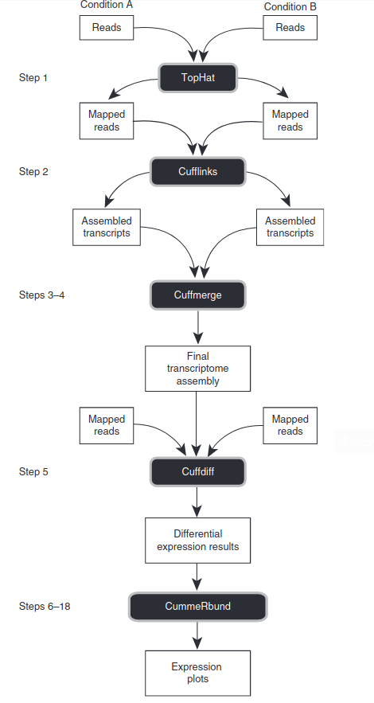

“Differential gene and transcript expression analysis of RNA-seq experiments with TopHat and Cufflinks” https://www.nature.com/articles/nprot.2012.016

https://m.blog.naver.com/hyeiny119/220940227755

With tuxedo protocol, you can assemble transcriptome from raw sequencing reads and find out stuff about the expression regulation or expression level of your gene of interest. TopHat is a rapid, highly efficient aligner for RNA-seq dadta. Uses bowtie internally. Bowtie2 is a DNA aligner.

## Read alignment with TopHat

TopHat is a short read aligner, fast splice junction mapper for RNA-seq reads to reference genome. It aligns RNA-seq reads to mammalian-sized genomes using the ultra high-throughput short read aligner Bowtie, and then anlyzes the mapping resulst to identify splice junctions between exons. For exon mapping, exon needs to be cut into pieces for mapping to take place. This is why we need tuxedo tool. So when you input gtf file, it’s mapped to transcriptome. If reads are not mapped to the transcriptome, they are mapped to the genome and looked for skipped exons. These exons are cut into pieces and mapped to make a whole new geneset file.

The following link is a hell of a site about NGS analysis, with thorough explanation on TopHat pipeline. [Aligning RNA-seq data](https://learn.gencore.bio.nyu.edu/rna-seq-analysis/aligning-rna-seq-data/)

Also, this is the original article describing the inner workings of TopHat: [TopHat: discovering splice junctions with RNA-Seq](https://academic.oup.com/bioinformatics/article/25/9/1105/203994)

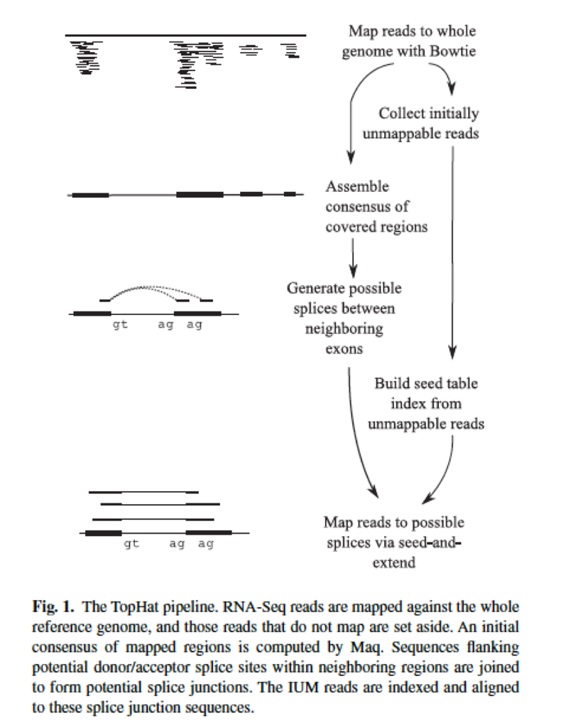

### 1. Input file

TopHat uses reference genome (in this case part of hg19, only chr 1) to align short RNA-seq reads, therefore we need human reference sequence and RNA-seq raw read. `.fastq` files are the RNA-seq raw reads, and `SampleReference.fa` is the edited shorter version of UCSC hg19 human genome reference sequence. The files with SampleReference as their prefix are Bowtie index files.

### 2. Running TopHat

Execute TopHat2.

`-o` designates output directory, and then you gotta put in reference genome + its index file prefix after that, and then the raw read files of paired-end reads come afterwards.

`tophat -o [output_directory/] [SampleReference_prefix] [ShortRead_1_1.Fastq] [ShortRead_1_2.Fastq]`

```
[soh1@x020 RNAPreprocess]$ tophat -o tophat_188462/ Samplereference 188462_1.Fastq 188462_2.Fastq
```

```
[soh1@x020 RNAPreprocess]$ tophat -o tophat_188467/ SampleReference 188467_1.Fastq 188467_2.Fastq
```

The execution looks like this

```
[2020-08-10 15:02:10] Beginning TopHat run (v2.1.1)
-----------------------------------------------
[2020-08-10 15:02:10] Checking for Bowtie
          Bowtie version:    2.3.4.1
[2020-08-10 15:02:10] Checking for Bowtie index files (genome)..
    Found both Bowtie1 and Bowtie2 indexes.
[2020-08-10 15:02:10] Checking for reference FASTA file
[2020-08-10 15:02:10] Generating SAM header for SampleReference
[2020-08-10 15:02:10] Preparing reads
     left reads: min. length=76, max. length=76, 137084 kept reads (1 discarded)
    right reads: min. length=76, max. length=76, 137079 kept reads (6 discarded)
[2020-08-10 15:02:14] Mapping left_kept_reads to genome SampleReference with Bowtie2
[2020-08-10 15:02:20] Mapping left_kept_reads_seg1 to genome SampleReference with Bowtie2 (1/3)
[2020-08-10 15:02:20] Mapping left_kept_reads_seg2 to genome SampleReference with Bowtie2 (2/3)
[2020-08-10 15:02:21] Mapping left_kept_reads_seg3 to genome SampleReference with Bowtie2 (3/3)
[2020-08-10 15:02:21] Mapping right_kept_reads to genome SampleReference with Bowtie2
[2020-08-10 15:02:32] Mapping right_kept_reads_seg1 to genome SampleReference with Bowtie2 (1/3)
[2020-08-10 15:02:32] Mapping right_kept_reads_seg2 to genome SampleReference with Bowtie2 (2/3)
[2020-08-10 15:02:33] Mapping right_kept_reads_seg3 to genome SampleReference with Bowtie2 (3/3)
[2020-08-10 15:02:34] Searching for junctions via segment mapping
[2020-08-10 15:02:37] Retrieving sequences for splices
[2020-08-10 15:02:37] Indexing splices
Building a SMALL index
[2020-08-10 15:02:38] Mapping left_kept_reads_seg1 to genome segment_juncs with Bowtie2 (1/3)
[2020-08-10 15:02:39] Mapping left_kept_reads_seg2 to genome segment_juncs with Bowtie2 (2/3)
[2020-08-10 15:02:39] Mapping left_kept_reads_seg3 to genome segment_juncs with Bowtie2 (3/3)
[2020-08-10 15:02:39] Joining segment hits
[2020-08-10 15:02:39] Mapping right_kept_reads_seg1 to genome segment_juncs with Bowtie2 (1/3)
[2020-08-10 15:02:40] Mapping right_kept_reads_seg2 to genome segment_juncs with Bowtie2 (2/3)
[2020-08-10 15:02:40] Mapping right_kept_reads_seg3 to genome segment_juncs with Bowtie2 (3/3)
[2020-08-10 15:02:40] Joining segment hits
[2020-08-10 15:02:40] Reporting output tracks
-----------------------------------------------
[2020-08-10 15:02:53] A summary of the alignment counts can be found in tophat_188467//align_summary.txt
[2020-08-10 15:02:53] Run complete: 00:00:42 elapsed
```

### 3. TopHat Result

Check the results

```
[soh1@x020 RNAPreprocess]$ cd tophat_188462
```

```
[soh1@x020 tophat_188462]$ ls -lah
```

The output looks like this:

```
[soh1@x020 tophat_188462]$ ls -lah
total 7.0M
drwxrwxr-x  3 soh1 soh1 4.0K Aug 10 14:30 .
drwxrwxr-x 20 soh1 soh1 4.0K Aug  8 23:07 ..
-rw-rw-r--  1 soh1 soh1 6.7M Aug 10 14:30 accepted_hits.bam
-rw-rw-r--  1 soh1 soh1  557 Aug 10 14:30 align_summary.txt
-rw-rw-r--  1 soh1 soh1 3.5K Aug 10 14:30 deletions.bed
-rw-rw-r--  1 soh1 soh1 1.4K Aug 10 14:30 insertions.bed
-rw-rw-r--  1 soh1 soh1  15K Aug 10 14:30 junctions.bed
drwxrwxr-x  2 soh1 soh1 4.0K Aug 10 14:30 logs
-rw-rw-r--  1 soh1 soh1  172 Aug 10 14:29 prep_reads.info
-rw-rw-r--  1 soh1 soh1 280K Aug 10 14:30 unmapped.bam
```

`accepted_hits.bam` file is the aligned reads, `deletions.bed`, `insertions.bed`, and `junctions.bed` files contain the InDel and Junction information that are found during alignment. Check out the aligned reads. BAM files are binary, so convert it into SAM format with SAMtools.

```
ERR188462.9643448       163     chr1    11627   50      75M     =       11763   211     TTTCTCCAC
AAAGTGTTTACTTTTGGATTTTTGCCAGTCTAACAGGTGAAGCCCTGGAGATTCTTATTAGTGATT     @@@DFFFFHHHHHHIJGJIGICHGJG
FHGHIJIGJJJIJJGEHIEHGHGIGHGHHIGFIHIJIJIJJGGHGHGGD     AS:i:0  XN:i:0  XM:i:0  XO:i:0  XG:i:0  NM:
i:0  MD:Z:75 YT:Z:UU NH:i:1
ERR188462.9643448       83      chr1    11763   50      75M     =       11627   -211    CGGTGTTGA
GAATGACTGCGCAAATTTGCCGGATTTCCTTTGCTGTTCCTGCATGTAGTTTAAACGAGATTGCCA     BBCCCCDCDEEEEEEHDIIIHEGGGI
HGBIIGGFGGGHEHHCAF?IGDIIHCEECBH@HHECA:DHDDDDDA@@@     AS:i:0  XN:i:0  XM:i:0  XO:i:0  XG:i:0  NM:
i:0  MD:Z:75 YT:Z:UU NH:i:1
```

## Expression Quantification with Cufflinks

### 1. Input file

Cufflinks takes in these input files: BAM file either from TopHat or HiSAT2 (`accepted_hits.bam` file from TopHat or `AlignedResult.sorted.bam` from HiSAT2), and the edited version of UCSC hg19 annotation file called `gene.gtf`.

### 2. Running Cufflinks

Usage

```
cufflinks -G [gene_annotation_file.gtf] -o [output_directory] --no-update-check
```

-G Go up one directory again into RNAPreprocessing and enter the following command.

```
cufflinks -G SampleGenes.gtf -o cufflinks_188462 --no-update-check tophat_188462/accepted_hits.bam
```

```
cufflinks -G SampleGenes.gtf -o cufflinks_188467 --no-update-check tophat_188467/accepted_hits.bam
```

Here’s the full usage of cufflinks

```
cufflinks v2.2.1
linked against Boost version 104700
-----------------------------
Usage:   cufflinks [options] <hits.sam>
General Options:
  -o/--output-dir              write all output files to this directory              [ default:     ./ ]
  -p/--num-threads             number of threads used during analysis                [ default:      1 ]
  --seed                       value of random number generator seed                 [ default:      0 ]
  -G/--GTF                     quantitate against reference transcript annotations
  -g/--GTF-guide               use reference transcript annotation to guide assembly
  -M/--mask-file               ignore all alignment within transcripts in this file
  -b/--frag-bias-correct       use bias correction - reference fasta required        [ default:   NULL ]
  -u/--multi-read-correct      use 'rescue method' for multi-reads (more accurate)   [ default:  FALSE ]
  --library-type               library prep used for input reads                     [ default:  below ]
  --library-norm-method        Method used to normalize library sizes                [ default:  below ]

Advanced Abundance Estimation Options:
  -m/--frag-len-mean           average fragment length (unpaired reads only)         [ default:    200 ]
  -s/--frag-len-std-dev        fragment length std deviation (unpaired reads only)   [ default:     80 ]
  --max-mle-iterations         maximum iterations allowed for MLE calculation        [ default:   5000 ]
  --compatible-hits-norm       count hits compatible with reference RNAs only        [ default:  FALSE ]
  --total-hits-norm            count all hits for normalization                      [ default:  TRUE  ]
  --num-frag-count-draws       Number of fragment generation samples                 [ default:    100 ]
  --num-frag-assign-draws      Number of fragment assignment samples per generation  [ default:     50 ]
  --max-frag-multihits         Maximum number of alignments allowed per fragment     [ default: unlim  ]
  --no-effective-length-correction   No effective length correction                  [ default:  FALSE ]
  --no-length-correction       No length correction                                  [ default:  FALSE ]
  -N/--upper-quartile-norm     Deprecated, use --library-norm-method                 [    DEPRECATED   ]
  --raw-mapped-norm            Deprecated, use --library-norm-method                 [    DEPRECATED   ]

Advanced Assembly Options:
  -L/--label                   assembled transcripts have this ID prefix             [ default:   CUFF ]
  -F/--min-isoform-fraction    suppress transcripts below this abundance level       [ default:   0.10 ]
  -j/--pre-mrna-fraction       suppress intra-intronic transcripts below this level  [ default:   0.15 ]
  -I/--max-intron-length       ignore alignments with gaps longer than this          [ default: 300000 ]
  -a/--junc-alpha              alpha for junction binomial test filter               [ default:  0.001 ]
  -A/--small-anchor-fraction   percent read overhang taken as 'suspiciously small'   [ default:   0.09 ]
  --min-frags-per-transfrag    minimum number of fragments needed for new transfrags [ default:     10 ]
  --overhang-tolerance         number of terminal exon bp to tolerate in introns     [ default:      8 ]
  --max-bundle-length          maximum genomic length allowed for a given bundle     [ default:3500000 ]
  --max-bundle-frags           maximum fragments allowed in a bundle before skipping [ default: 500000 ]
  --min-intron-length          minimum intron size allowed in genome                 [ default:     50 ]
  --trim-3-avgcov-thresh       minimum avg coverage required to attempt 3' trimming  [ default:     10 ]
  --trim-3-dropoff-frac        fraction of avg coverage below which to trim 3' end   [ default:    0.1 ]
  --max-multiread-fraction     maximum fraction of allowed multireads per transcript [ default:   0.75 ]
  --overlap-radius             maximum gap size to fill between transfrags (in bp)   [ default:     50 ]

Advanced Reference Annotation Guided Assembly Options:
  --no-faux-reads              disable tiling by faux reads                          [ default:  FALSE ]
  --3-overhang-tolerance       overhang allowed on 3' end when merging with reference[ default:    600 ]
  --intron-overhang-tolerance  overhang allowed inside reference intron when merging [ default:     30 ]

Advanced Program Behavior Options:
  -v/--verbose                 log-friendly verbose processing (no progress bar)     [ default:  FALSE ]
  -q/--quiet                   log-friendly quiet processing (no progress bar)       [ default:  FALSE ]
  --no-update-check            do not contact server to check for update availability[ default:  FALSE ]

Supported library types:
    ff-firststrand
    ff-secondstrand
    ff-unstranded
    fr-firststrand
    fr-secondstrand
    fr-unstranded (default)
    transfrags

Supported library normalization methods:
    classic-fpkm
```

You can see that `-G` means `--GTF` and it means that you’re going to designate which reference transcript annotation file in GTF file format you’re gonna use. `-o` designates the output directory, and `--no-update-check` for not trying to contact server to check for cufflinks update availability. We use the `accepted_hits.bam` that are products of TopHat operation. The whole process actually takes about 30min. ~ 3 hours depending on file size, but since this is practice the file sizes are minimal.

Check for the results by looking at `genes.fpkm_tracking` and `isoforms.fpkm_tracking`.

```
[soh1@x020 RNAPreprocess]$ cd cufflinks_188462
[soh1@x020 cufflinks_188462]$ ls
genes.fpkm_tracking  isoforms.fpkm_tracking  skipped.gtf  transcripts.gtf
```

The files look like this.

```
[soh1@x020 cufflinks_188462]$ cat genes.fpkm_tracking | less

tracking_id     class_code      nearest_ref_id  gene_id gene_short_name tss_id  locus   length  coverage        FPKM    FPKM_conf_lo    FPKM_conf_hi    FPKM_status
WASH7P  -       -       WASH7P  WASH7P  TSS7245 chr1:14361-29370        -       -       5404.08 4943.22 5864.94 OK
FAM138F -       -       FAM138F FAM138F TSS8099 chr1:34610-36081        -       -       0       0       0       OK
OR4F5   -       -       OR4F5   OR4F5   TSS13903        chr1:69090-70008        -       -       0       0       0       OK
LOC729737       -       -       LOC729737       LOC729737       TSS17868        chr1:136697-140566      -       -       232.788 166.8   298.777 OK
LOC100132287    -       -       LOC100132287    LOC100132287    TSS11868        chr1:323891-328581      -       -       0.063928        0       7.22557 OK
LOC100133331    -       -       LOC100133331    LOC100133331    TSS11868        chr1:323891-328581      -       -       399.44  320.127 478.754 OK
OR4F29  -       -       OR4F29  OR4F29  TSS4765 chr1:367658-368597      -       -       0       0       0       OK
OR4F29  -       -       OR4F29  OR4F29  TSS12223        chr1:621095-622034      -       -       0       0       0       OK
LOC100133331    -       -       LOC100133331    LOC100133331    TSS12588        chr1:661138-665731      -       -       585.403 492.653 678.153 OK
LOC100288069    -       -       LOC100288069    LOC100288069    TSS8390 chr1:700244-714068      -       -       395.15  252.441 537.859 OK
NCRNA00115      -       -       NCRNA00115      NCRNA00115      TSS4759 chr1:761585-762902      -       -       577.91  400.361 755.46  OK
LOC643837       -       -       LOC643837       LOC643837       TSS9883 chr1:763063-789740      -       -       1375.08 1126.08 1624.07 OK
FAM41C  -       -       FAM41C  FAM41C  TSS20108        chr1:803450-812182      -       -       29.8483 0       64.3141 OK
LOC100130417    -       -       LOC100130417    LOC100130417    TSS19488        chr1:852952-854817      -       -       0       0       0       OK
SAMD11  -       -       SAMD11  SAMD11  TSS27307        chr1:861120-879961      -       -       5.26444e-06     0       12.7057 OK
NOC2L   -       -       NOC2L   NOC2L   TSS17209        chr1:879582-894679      -       -       13760.4 12957.3 14563.5 OK
KLHL17  -       -       KLHL17  KLHL17  TSS16950        chr1:895966-901099      -       -       1312.62 1128.94 1496.3  OK
PLEKHN1 -       -       PLEKHN1 PLEKHN1 TSS11643        chr1:901876-910484      -       -       115.587 55.294  175.879 OK
C1orf170        -       -       C1orf170        C1orf170        TSS8292 chr1:910578-917473      -       -       36.838  8.9911  64.685  OK
HES4    -       -       HES4    HES4    TSS26133        chr1:934341-935552      -       -       496.54  294.911 698.169 OK
ISG15   -       -       ISG15   ISG15   TSS15759        chr1:948846-949919      -       -       175583  170786  180381  OK
AGRN    -       -       AGRN    AGRN    TSS19566        chr1:955502-991492      -       -       4328.3  4137.78 4518.82 OK
```

```
[soh1@x020 cufflinks_188462]$ cat isoforms.fpkm_tracking | less

tracking_id     class_code      nearest_ref_id  gene_id gene_short_name tss_id  locus   length  coverage        FPKM    FPKM_conf_lo    FPKM_conf_hi    FPKM_status
NR_024540       -       -       WASH7P  WASH7P  TSS7245 chr1:14361-29370        1769    50.5077 5404.08 4943.22 5864.94 OK
NR_026820       -       -       FAM138F FAM138F TSS8099 chr1:34610-36081        1130    0       0       0       0       OK
NM_001005484    -       -       OR4F5   OR4F5   TSS13903        chr1:69090-70008        918     0       0       0       0       OK
NR_039983       -       -       LOC729737       LOC729737       TSS17868        chr1:136697-140566      3402    1.69647 232.788 166.8   298.777 OK
NR_028322       -       -       LOC100132287    LOC100132287    TSS11868        chr1:323891-328581      4370    0.0004964       0.063928        0       7.22557 OK
NR_028327_1     -       -       LOC100133331    LOC100133331    TSS11868        chr1:323891-328581      4273    3.10165 399.44  320.127 478.754 OK
NM_001005221    -       -       OR4F29  OR4F29  TSS4765 chr1:367658-368597      939     0       0       0       0       OK
NM_001005221_1  -       -       OR4F29  OR4F29  TSS12223        chr1:621095-622034      939     0       0       0       0       OK
NR_028327_2     -       -       LOC100133331    LOC100133331    TSS12588        chr1:661138-665731      4273    4.66793 585.403 492.653 678.153 OK
NR_033908       -       -       LOC100288069    LOC100288069    TSS8390 chr1:700244-714068      1371    3.31437 395.15  252.441 537.859 OK
NR_024321       -       -       NCRNA00115      NCRNA00115      TSS4759 chr1:761585-762902      1317    5.35406 577.91  400.361 755.46  OK
NR_015368       -       -       LOC643837       LOC643837       TSS9883 chr1:763063-789740      1543    12.9108 1375.08 1126.08 1624.07 OK
NR_027055       -       -       FAM41C  FAM41C  TSS20108        chr1:803450-812182      1706    0.300427        29.8483 0       64.3141 OK
NR_026874       -       -       LOC100130417    LOC100130417    TSS19488        chr1:852952-854817      496     0       0       0       0       OK
NM_152486       -       -       SAMD11  SAMD11  TSS27307        chr1:861120-879961      2554    5.1121e-08      5.26444e-06     0       12.7057 OK
NM_015658       -       -       NOC2L   NOC2L   TSS17209        chr1:879582-894679      2800    133.622 13760.4 12957.3 14563.5 OK
NM_198317       -       -       KLHL17  KLHL17  TSS16950        chr1:895966-901099      2564    12.2319 1312.62 1128.94 1496.3  OK
NM_001160184    -       -       PLEKHN1 PLEKHN1 TSS11643        chr1:901876-910484      2295    0.000108946     0.0115006       0       14.2941 OK
NM_032129       -       -       PLEKHN1 PLEKHN1 TSS11643        chr1:901876-910484      2400    1.09485 115.575 57.1677 173.983 OK
NR_027693       -       -       C1orf170        C1orf170        TSS8292 chr1:910578-917473      3040    0.344296        36.838  8.9911  64.685  OK
NM_021170       -       -       HES4    HES4    TSS26133        chr1:934341-935552      962     2.25424 323.505 138.059 508.951 OK
NM_001142467    -       -       HES4    HES4    TSS26133        chr1:934343-935552      1038    1.20574 173.035 33.9317 312.139 OK
NM_005101       -       -       ISG15   ISG15   TSS15759        chr1:948846-949919      666     1686.71 175583  170786  180381  OK
NM_198576       -       -       AGRN    AGRN    TSS19566        chr1:955502-991492      7319    41.6659 4328.3  4137.78 4518.82 OK
```

FPKM is similar to RPKM, but because paired-end reads have two fragments (left fragment, right fragment) per read, however it cannot always exactly equal twice that of RPKM (~x2: it’s about 2 times) due to unmapped fragments (example: only one of the pair is mapped). Therefore we call it fragments per kilobase (of exon model) per millions of mapped reads. Refer to this [blog article](https://bgreat.tistory.com/97) for clarification. It’s a pretty good read.

### 3. Master transcriptome using cuffmerge

The main purpose of Cufflinks.cuffmerge is to merge together several Cufflinks assemblies, making it easier to produce an assembly GTF file suitable for use with Cufflinks.cuffdiff. Cufflinks.cuffmerge also runs Cuffcompare in the background and automatically filters out transcribed fragments (transfrags) that are likely to be artifacts. Cuffmerge is basically a “meta-assembler” because it treats the assembled transfrags from Cufflinks the way that Cufflinks treats reads, by merging them together parsimoniously (more succinctly).[^1]

Cuffmerge usage

```
Usage:
    cuffmerge [Options] <assembly_GTF_list.txt>

Options:
    -h/--help                               Prints the help message and exits
    -o                     <output_dir>     Directory where merged assembly will be written  [ default: ./merged_asm  ]
    -g/--ref-gtf                            An optional "reference" annotation GTF.
    -s/--ref-sequence      <seq_dir>/<seq_fasta> Genomic DNA sequences for the reference.
    --min-isoform-fraction <0-1.0>          Discard isoforms with abundance below this       [ default:           0.05 ]
    -p/--num-threads       <int>            Use this many threads to merge assemblies.       [ default:             1  ]
    --keep-tmp                              Keep all intermediate files during merge
```

`assemblies.txt` is the input file that contains the samples’ output paths.

```
[soh1@x020 RNAPreprocess]$ cat assemblies.txt
./cufflinks_188462/transcripts.gtf
./cufflinks_188467/transcripts.gtf
```

```
[soh1@x020 RNAPreprocess]$ cuffmerge -g SampleGenes.gtf -s SampleReference.fa -o merged_asm/ assemblies.txt
```

`merged.gtf` generated in ./merged_asm/ looks like this:

```
chr1    Cufflinks       exon    69091   70008   .       +       .       gene_id "XLOC_000001"; transcript_id "TCONS_00000001"; exon_number "1"; gene_name "OR4F5"; oId "NM_001005484"; nearest_ref "NM_001005484"; class_code "="; tss_id "TSS1"; p_id "P1";
chr1    Cufflinks       exon    323892  324060  .       +       .       gene_id "XLOC_000002"; transcript_id "TCONS_00000003"; exon_number "1"; gene_name "LOC100133331"; oId "NR_028327_1"; nearest_ref "NR_028327_1"; class_code "="; tss_id "TSS2";
```

### 4. Use cuffdiff to find significant change in gene expression (, splicing, and promoter use)

Cuffdiff usage: -q: log-friendly quiet processing -u: multi-read correct; tells cufflinks to do an initial estimation procedure to more -M: mask file; tells cufflinks to ignore transcripts that come from this gtf file. -N: –upper-quartile-norm; deprecated. Use `--library-norm-method quartile` instead. -b: use fragment bias correction - reference fasta required. This paper needs to be cited for using this option: [Improving RNA-Seq expression estimates by correcting for fragment bias](https://genomebiology.biomedcentral.com/articles/10.1186/gb-2011-12-3-r22). -> Non-uniformity in estimating expression levels need to be accounted for and corrected using a likelihood based approach. Correction of bias leads to improved replicability of results across libraries and sequencing technologies.

```
Usage:   cuffdiff [options] <transcripts.gtf> <sample1_hits.sam> <sample2_hits.sam> [... sampleN_hits.sam]
   Supply replicate SAMs as comma separated lists for each condition: sample1_rep1.sam,sample1_rep2.sam,...sample1_repM.sam
```

```
cuffdiff -q -u merged_asm/merged.gtf -N -o name-diff_out -b SampleReference.fa --no-update-check -L 188462,188467 tophat_188462/accepted_hits.bam tophat_188467/accepted_hits.bam
```

If you look at the output directory,

```
cd name-diff_out
cat isoform_exp.diff | less
```

```
test_id gene_id gene    locus   sample_1        sample_2        status  value_1 value_2 log2(fold_change)       test_stat       p_value q_value significant
TCONS_00000001  XLOC_000001     OR4F5   chr1:69090-70008        188462  188467  NOTEST  0       0       0       0       1       1       no
TCONS_00000002  XLOC_000002     LOC100132062    chr1:323891-328581      188462  188467  NOTEST  0.58516 0.599744        0.0355168       0       1       1       no
TCONS_00000003  XLOC_000002     LOC100133331    chr1:323891-328581      188462  188467  NOTEST  241.641 300.565 0.314812        0       1       1       no
TCONS_00000004  XLOC_000003     OR4F3   chr1:367658-368597      188462  188467  NOTEST  0       0       0       0       1       1       no
TCONS_00000005  XLOC_000004     LOC643837       chr1:763063-789740      188462  188467  OK      8135.09 8253.64 0.0208722       0.112415        0.9183  0.9183  no
TCONS_00000006  XLOC_000005     SAMD11  chr1:861120-894679      188462  188467  NOTEST  0       49.4547 inf     0       1       1       no
TCONS_00000007  XLOC_000006     KLHL17  chr1:895966-901099      188462  188467  OK      10453.6 11405.7 0.125763        0.904411        0.36235 0.498231        no
TCONS_00000008  XLOC_000007     PLEKHN1 chr1:901876-910484      188462  188467  NOTEST  0.0566352       302.099 12.381  0       1       1       no
TCONS_00000009  XLOC_000007     PLEKHN1 chr1:901876-910484      188462  188467  NOTEST  809.32  0.0139066       -15.8287        0       1       1       no
TCONS_00000010  XLOC_000008     ISG15   chr1:948846-949919      188462  188467  OK      70511.5 237619  1.75272 41.2387 5e-05   0.000275        yes
TCONS_00000011  XLOC_000009     AGRN    chr1:955502-991492      188462  188467  OK      30389.2 29471.3 -0.0442494      -0.98411        0.32005 0.498231        no
TCONS_00000012  XLOC_000010     WASH7P  chr1:14361-29370        188462  188467  OK      29349.2 36034.6 0.296064        3.58656 0.00035 0.00128333      yes
TCONS_00000013  XLOC_000011     FAM138A chr1:34610-36081        188462  188467  NOTEST  0       0       0       0       1       1       no
TCONS_00000014  XLOC_000012     LOC729737       chr1:136697-140566      188462  188467  NOTEST  166.632 812.465 2.28564 0       1       1       no
TCONS_00000015  XLOC_000013     OR4F16  chr1:621095-622034      188462  188467  NOTEST  0       0       0       0       1       1       no
TCONS_00000016  XLOC_000014     LOC100133331    chr1:661138-665731      188462  188467  OK      1497.6  1771.31 0.242164        1.00366 0.3165  0.498231        no
TCONS_00000017  XLOC_000015     LOC100288069    chr1:700244-714068      188462  188467  OK      1596.39 1316.92 -0.277646       -0.617005       0.53895 0.658717        no
TCONS_00000018  XLOC_000016     NCRNA00115      chr1:761585-762902      188462  188467  OK      3701.47 2641.89 -0.48653        -1.46668        0.1415  0.3113  no
TCONS_00000019  XLOC_000017     FAM41C  chr1:803450-812182      188462  188467  NOTEST  141.948 528.963 1.89781 0       1       1       no
TCONS_00000020  XLOC_000018     LOC100130417    chr1:852952-854817      188462  188467  NOTEST  0       242.082 inf     0       1       1       no
TCONS_00000021  XLOC_000019     NOC2L   chr1:861120-894679      188462  188467  OK      65862.7 85650.9 0.379008        6.55471 5e-05   0.000275        yes
TCONS_00000022  XLOC_000020     C1orf170        chr1:910578-917473      188462  188467  NOTEST  254.272 154.491 -0.718855       0       1       1       no
TCONS_00000023  XLOC_000021     HES4    chr1:934341-935552      188462  188467  OK      3140.33 0       -inf    -nan    0.09955 0.273763        no
TCONS_00000024  XLOC_000021     HES4    chr1:934341-935552      188462  188467  OK      1220.48 1280.26 0.0689796       0.0812733       0.9132  0.9183  no
```

# III. New Tuxedo Protocol

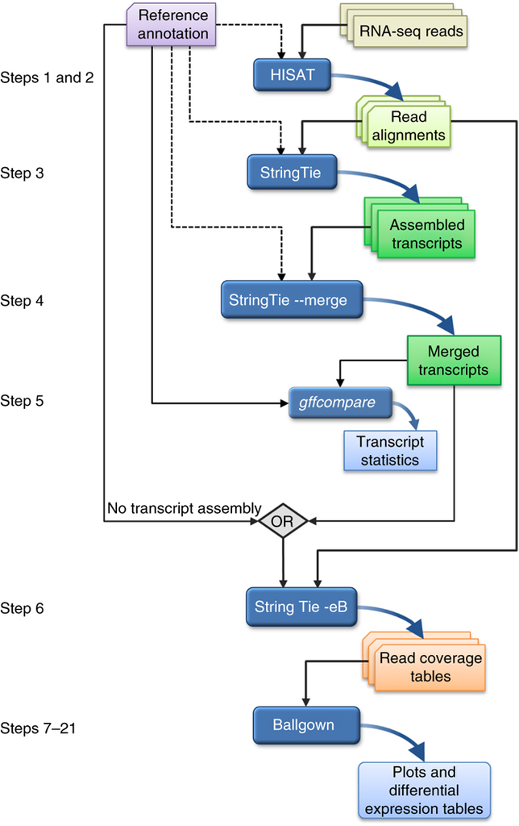

“Transcript-level expression analysis of RNA-seq experiments with HISAT, StringTie and Ballgown” https://www.nature.com/articles/nprot.2016.095

http://blog.naver.com/naturelove87/221969005451

So new tuxedo protocol involves HiSAT, StringTie, StringTie –merge, gffcompare, StringTie -eB, Ballgown

RNA-seq analysis can be divided into four steps:

1. Map reads to genome.
2. Assemble alignments to whole length reference transcript.
3. Quantify transcript for each gene.
4. Calculate expression level difference for all experimental conditions.

So, HiSAT is the aligner that maps RNA-seq reads to the reference genome and finds transcript splice sites (splice junctions). -> HiSAT2 aligns what it can, and for the rest of the unmapped reads, the software automatically finds out if they map to splice junctions that aren’t in the annotation. These alignments are used as input file for StringTie for assembly of transcript. StringTie assembles transcripts and quantify each isoform (expression level). (From reads, it infers what sort of transcript and how many copies of them are present.) After assembly of all the samples, all the set in the assembly are put into StringTie `merge`. `Merge`, as its name implies, merges transcripts in GTF/GFF files into a non-redundant set of transcripts. This mode is used in the new differential analysis pipeline to generate a global, unified set of transcripts (isoforms) across multiple RNA-seq samples. This step is necessary because for some samples, only portion of the transcriptome are covered as reads and consequently only a part of them are assembled into transcripts. This results in identical set of transcripts in all samples, without redundant transcripts and covering all unique transcripts. Then with `gffcompare` you can compare transcripts that are associated with the reference annotation, and also view the statistical report on it. However, because of changed transcript structure, reads need to be assigned again. So with `StringTie -eB`, reads are assigned again to transcripts and reference annotation. Finally StringTie recalculates the transcript amount and generates a new transcript (read coverage) table. If the `-G` option (reference annotation) is provided, StringTie will assemble the transfrags (transcribed fragment) from the input GTF files with the reference transcripts. Then all of this, read-count data + transcript + annotation, is passed onto Ballgown, which is the R/Bioconductor package for visualization of differentally expressed genes. Ballgown, with the transcripts and transcript quantitative information, determines differentially expressed gene and transcripts according to experimental condition.

## Short Read Alignment w/ HiSAT2

### 1. Input file

HiSAT2 aligns RNA-seq short reads to reference genome, therefore we need human reference genome sequence and RNA-seq read raw data. Here, we don’t have to prepare index files from Bowtie. We can generate index files through HiSAT2.

### 2. HiSAT2-build (building binary index of reference genome)

[hisat2-build indexer](https://ccb.jhu.edu/software/hisat2/manual.shtml#the-hisat2-build-indexer)

```
[soh1@x020 RNAPreprocess]$ hisat2-build SampleReference.fa SampleIndex
Settings:
  Output files: "SampleIndex.*.ht2"
  Line rate: 6 (line is 64 bytes)
  Lines per side: 1 (side is 64 bytes)
  Offset rate: 4 (one in 16)
.
.
.
(omitted)
.
.
.
    gbwtTotLen: 280000
    gbwtTotSz: 280000
    reverse: 0
    linearFM: Yes
Total time for call to driver() for forward index: 00:00:02
```

These are the index files used by HiSAT2, and the fasta file is no longer required for further process in aligning the reads after building these index files.

```
[soh1@x020 RNAPreprocess]$ ls | grep "SampleIndex*"
SampleIndex.1.ht2
SampleIndex.2.ht2
SampleIndex.3.ht2
SampleIndex.4.ht2
SampleIndex.5.ht2
SampleIndex.6.ht2
SampleIndex.7.ht2
SampleIndex.8.ht2
```

### 3. Execute HiSAT2 for alignment

We don’t need the .fa file any more, because index files by the name of SampleIndex (prefix) are all we need. -q: It’s fastq file that we’re aligning. -x: This is the index file prefix -1: first paired-end fastq file -2: second paired-end fastq file -S: output file location

```
hisat2 -q -x SampleIndex -1 188462_1.Fastq -2 188462_2.Fastq -S hisat2_188462/AlignedResult.sam
hisat2 -q -x SampleIndex -1 188467_1.Fastq -2 188467_2.Fastq -S hisat2_188467/AlignedResult.sam
```

## Quantitate Expression Level with StringTie

### 1. Input file

StringTie’s input also uses TopHat’s output `accepted_hits.bam` or HiSAT2 `ouput AlignedResult.sorted.bam` along with UCSC hg19 `gene.gtf` annotation file. New Tuxedo pipeline uses StringTie.

### 2. Execute StringTie

The textbook says we have to use AlignedResult.sorted.bam, which of course we don’t have. But remember, we obtained sam files (hisat2_188462/AlignedResult.sam and hisat2_188467/AlignedResult.sam) by aligning the short reads to the reference genome SampleReference.fa. We can use samtools to convert these to bam files and sort them.

[Usage:](http://www.htslib.org/doc/samtools.html)

`samtools view -bt ref_list.txt -o aln.bam aln.sam.gz`

`samtools sort -T /tmp/aln.sorted -o aln.sorted.bam aln.bam`

Do this for both `hisat2_188462/AlignedResult.sam` and `hisat2_188467/AlignedResult.sam.`

```
cd hisat2_188462
samtools view -b AlignedResult.sam | samtools sort -T /tmp/AlignedResult.sorted -o AlignedResult.sorted.bam -
cd ../hisat2_188467
samtools view -b AlignedResult.sam | samtools sort -T /tmp/AlignedResult.sorted -o AlignedResult.sorted.bam -
```

You can also use -Sb option instead of single -b, although -S option that designates the input file format as sam is deprecated. Nowadays, samtools automatically detects the input file format.

-T: temporary files and directory -o: output file name -: input bam file (gets passed on by the pipe operator from samtools view bam format.)

```
stringtie -G SampleGenes.gtf -l ERR188462 -o ./stringtie_188462/STRG_AlignedResult.gtf hisat2_188462/AlignedResult.sorted.bam
stringtie -G SampleGenes.gtf -l ERR188467 -o ./stringtie_188467/STRG_AlignedResult.gtf hisat2_188467/AlignedResult.sorted.bam
```

The resulting gtf file looks like this:

```
[soh1@x020 RNAPreprocess]$ head stringtie_188467/STRG_AlignedResult.gtf
# stringtie -G SampleGenes.gtf -l ERR188467 -o ./stringtie_188467/STRG_AlignedResult.gtf hisat2_188467/AlignedResult.sorted.bam
# StringTie version 2.0.6
chr1    StringTie       transcript      14362   29370   1000    -       .       gene_id "ERR188467.1"; transcript_id "ERR188467.1.1"; reference_id "NR_024540"; ref_gene_id "WASH7P"; ref_gene_name "WASH7P"; cov "41.344620"; FPKM "2034.181396"; TPM "12973.078125";
chr1    StringTie       exon    14362   14829   1000    -       .       gene_id "ERR188467.1"; transcript_id "ERR188467.1.1"; exon_number "1"; reference_id "NR_024540"; ref_gene_id "WASH7P"; ref_gene_name "WASH7P"; cov "72.759926";
chr1    StringTie       exon    14970   15038   1000    -       .       gene_id "ERR188467.1"; transcript_id "ERR188467.1.1"; exon_number "2"; reference_id "NR_024540"; ref_gene_id "WASH7P"; ref_gene_name "WASH7P"; cov "88.698502";
chr1    StringTie       exon    15796   15947   1000    -       .       gene_id "ERR188467.1"; transcript_id "ERR188467.1.1"; exon_number "3"; reference_id "NR_024540"; ref_gene_id "WASH7P"; ref_gene_name "WASH7P"; cov "20.305109";
chr1    StringTie       exon    16607   16765   1000    -       .       gene_id "ERR188467.1"; transcript_id "ERR188467.1.1"; exon_number "4"; reference_id "NR_024540"; ref_gene_id "WASH7P"; ref_gene_name "WASH7P"; cov "3.586399";
chr1    StringTie       exon    16858   17055   1000    -       .       gene_id "ERR188467.1"; transcript_id "ERR188467.1.1"; exon_number "5"; reference_id "NR_024540"; ref_gene_id "WASH7P"; ref_gene_name "WASH7P"; cov "12.253215";
chr1    StringTie       exon    17233   17368   1000    -       .       gene_id "ERR188467.1"; transcript_id "ERR188467.1.1"; exon_number "6"; reference_id "NR_024540"; ref_gene_id "WASH7P"; ref_gene_name "WASH7P"; cov "58.980251";
chr1    StringTie       exon    17606   17742   1000    -       .       gene_id "ERR188467.1"; transcript_id "ERR188467.1.1"; exon_number "7"; reference_id "NR_024540"; ref_gene_id "WASH7P"; ref_gene_name "WASH7P"; cov "72.010948";
```

`gene_id` and `transcript_id` are the labels we gave to the samples through the -l option. StringTie arbitrarily decides and distributes the IDs. `reference_id` and `reference_gene_name`, etc. are information annotated by what’s found on the reference genome and gtf. cov is the average coverage value of the transcript.

## Merge the transcript data of all samples according to the Gene Annotation

All right. So GFF2 format is a flat tab-delimited file, each line of which corresponds to an annotation, or feature. Each line has nine columns and looks like the following:

> Chr1 curated CDS 365647 365963 . + 1 Transcript “R119.7”

The actual look into file looks like this:

```
chr1    unknown exon    14362   14829   .       -       .       gene_id "WASH7P"; gene_name "WASH7P"; transcript_id "NR_024540"; tss_id "TSS7245";
chr1    unknown exon    14970   15038   .       -       .       gene_id "WASH7P"; gene_name "WASH7P"; transcript_id "NR_024540"; tss_id "TSS7245";
chr1    unknown exon    15796   15947   .       -       .       gene_id "WASH7P"; gene_name "WASH7P"; transcript_id "NR_024540"; tss_id "TSS7245";
chr1    unknown exon    16607   16765   .       -       .       gene_id "WASH7P"; gene_name "WASH7P"; transcript_id "NR_024540"; tss_id "TSS7245";
```

So we’re gonna merge the transcript info into one, nicely unified file that contains all the infos about partial infos of transcripts in each sample. In the merge mode, StringTie takes as input a list of GTF/GFF files and merges/assembles these transcripts into a non-redundant set of transcripts. This mode is used in the new differential analysis pipeline to generate a global, unified set of transcripts (isoforms) across multiple RNA-Seq samples. [Usage link: search for “–merge”](http://ccb.jhu.edu/software/stringtie/index.shtml?t=manual) Output is a merged GTF file with merged gene models, but without any numeric results on coverage, FPKM, and TPM. Therefore, with this merged GTF, StringTie must re-estimate abundances by running it again with the -e option on the original set of alignment files, as illustrated in the figure below. This figure nicely illustrates the whole picture of differential expression analysis pipeline.

Differential Expression Analysis Pipeline

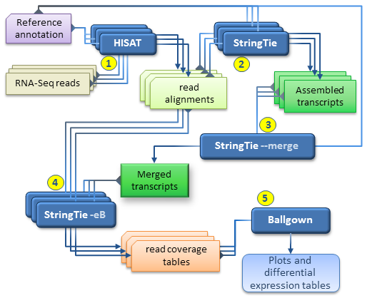

Shorter, faster DE Workflow When No Novel Isoforms Are Found

Novel isoforms in this case mean the assembled transcripts that are present in the samples but are missing from the reference annotation. Therefore, this process only considers the transcripts that are annotated by the reference annotation file (gtf).

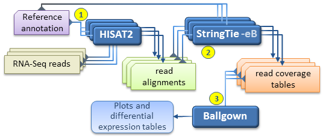

```
Transcript merge usage mode:
  stringtie --merge [Options] { gtf_list | strg1.gtf ...}
With this option StringTie will assemble transcripts from multiple
input files generating a unified non-redundant set of isoforms. In this mode
the following options are available:
  -G <guide_gff>   reference annotation to include in the merging (GTF/GFF3)
  -o <out_gtf>     output file name for the merged transcripts GTF
                    (default: stdout)
  -m <min_len>     minimum input transcript length to include in the merge
                    (default: 50)
  -c <min_cov>     minimum input transcript coverage to include in the merge
                    (default: 0)
  -F <min_fpkm>    minimum input transcript FPKM to include in the merge
                    (default: 1.0)
  -T <min_tpm>     minimum input transcript TPM to include in the merge
                    (default: 1.0)
  -f <min_iso>     minimum isoform fraction (default: 0.01)
  -g <gap_len>     gap between transcripts to merge together (default: 250)
  -i               keep merged transcripts with retained introns; by default
                   these are not kept unless there is strong evidence for them
  -l <label>       name prefix for output transcripts (default: MSTRG)
```

So this is what the `stringtie --merge` usage looks like. Note that { gtf_ list } can be a textfile that contains the list of files to be merged.

- -G option designates the reference annotation to include in the merging. The file format should either be in GTF of GFF3.
- -o option designates the output file name for the merged transcripts GTF.

Then you give gtf list as mentioned above as gtf_list, and in this case, is mergelists.txt.

The thing is, the path are not designated correctly, so you must make correction to the textfile mergelists.txt.

For example, the paths in my mergelists.txt was `/home/GDA/RNAPreprocess/stringtie_188462/STRG_AlignedResult.gtf` and `/home/GDA/RNAPreprocess/stringtie_188467/STRG_AlignedResult.gtf`, therefore gave errors like below:

`Error: cannot find file '/home/GDA/RNAPreprocess/stringtie_188462/STRG_AlignedResult.gtf'`

So I changed the directory correctly to where the files were located by vim. Then I executed the following code.

```
stringtie --merge -G SampleGenes.gtf -o stringtie_merged.gtf mergelists.txt

head stringtie_merge.gtf
```

The file looks something like this:

```
# stringtie --merge -G SampleGenes.gtf -o stringtie_merged.gtf mergelists.txt
# StringTie version 2.0.6
chr1    StringTie       transcript      14362   21859   1000    -       .       gene_id "MSTRG.1"; transcript_id "MSTRG.1.1";
chr1    StringTie       exon    14362   14829   1000    -       .       gene_id "MSTRG.1"; transcript_id "MSTRG.1.1"; exon_number "1";
chr1    StringTie       exon    14970   15038   1000    -       .       gene_id "MSTRG.1"; transcript_id "MSTRG.1.1"; exon_number "2";
chr1    StringTie       exon    15796   16765   1000    -       .       gene_id "MSTRG.1"; transcript_id "MSTRG.1.1"; exon_number "3";
chr1    StringTie       exon    16858   17055   1000    -       .       gene_id "MSTRG.1"; transcript_id "MSTRG.1.1"; exon_number "4";
chr1    StringTie       exon    17233   17368   1000    -       .       gene_id "MSTRG.1"; transcript_id "MSTRG.1.1"; exon_number "5";
chr1    StringTie       exon    17606   17742   1000    -       .       gene_id "MSTRG.1"; transcript_id "MSTRG.1.1"; exon_number "6";
chr1    StringTie       exon    17915   18061   1000    -       .       gene_id "MSTRG.1"; transcript_id "MSTRG.1.1"; exon_number "7";
```

## Compare the detected transcripts with the Reference Genome Annotation w/ [`gffcompare`](https://www.ncbi.nlm.nih.gov/pmc/articles/PMC7222033/)

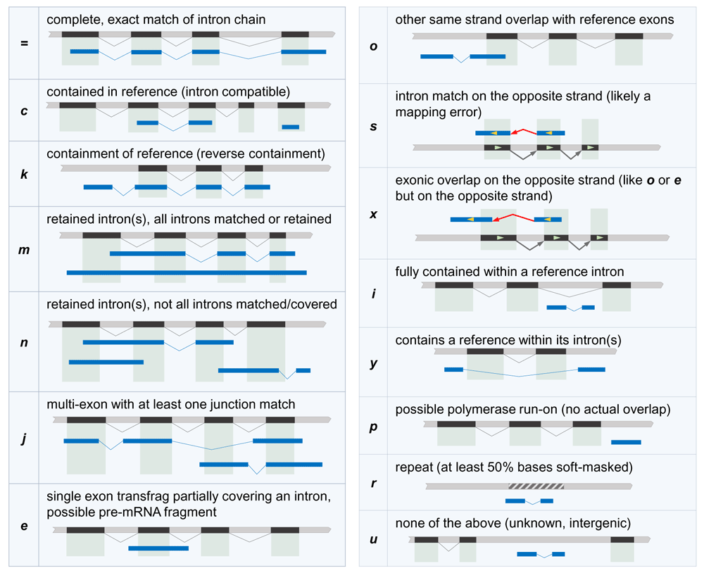

Here we can compare gff file and the detected/merged transcript file (gtf) and see how much of the detected transcripts align with the known reference genomic transcripts via **sensitivity** (the more known transcript, the more sensitivity), and how many are false positives, novel or de novo transcripts, novel exons, novel introns, or new splicing sites, etc via low **precision** (the less transcript isoforms are clustered together, the more chance of novel transcripts/new splice sites/new exon or introns (or even high false posistive rate)).

## stringtie -eB: Align the transcript data to gtf file (merged gtf; `stringtie_merged.gtf`) and Estimate the Expression Level

Remember that merged gtf (`stringtie_merged.gtf`) does not contain the expression level data of transcripts, only the transcript names. So we need to re-estimate the abundances (coverage, FPKM, TPM) on the original alignment files.

The usage goes like this:

- -e only estimate the abundance of given reference transcripts (requires -G)
- -B enable output of Ballgown table files which will be created in the same directory as the output GTF (requires -G, -o recommended) (SAME DIRECTORY. -b would need desginated)
- -G reference annotation to use for guiding the assembly process (GTF/GFF3) = the merged GTF.

```
stringtie <input.bam ..> [options]
```

```
stringtie -eB -G stringtie_merged.gtf -o ballgown_188462/ERR_188462.gtf hisat2_188462/AlignedResult.sorted.bam
```

```
stringtie -eB -G stringtie_merged.gtf -o ballgown_188467/ERR_188467.gtf hisat2_188467/AlignedResult.sorted.bam
```

## Differentially Expressed Gene Analysis and Data Visualization

### 1. Input file

Check phenotype data (phenodata.csv). If we open phenodata.csv, it looks like this:

```
[soh1@x020 RNAPreprocess]$ cat phenodata.csv
"ids","sex","population"
"ERR188044","male","YRI"
"ERR188104","male","YRI"
"ERR188234","female","YRI"
"ERR188245","female","GBR"
"ERR188257","male","GBR"
"ERR188273","female","YRI"
"ERR188337","female","GBR"
"ERR188383","male","GBR"
"ERR188401","male","GBR"
"ERR188428","female","GBR"
"ERR188454","male","YRI"
"ERR204916","female","YRI"
```

First column corresponds to sample ID, second column corresponds to sex, and third column corresponds to racial information (YRI = Yoruba in Ibadan, Nigeria -> pertains to an African; GBR = British in England and Scotland -> pertains to a European) In ballgown/ directory, we have subdirectories of different samples (with different sample IDs), and files that have underwent the same pipeline that we have demonstrated above. Now let’s use R for further analysis.

### 2. Execute Ballgown

Ballgown is an R package. Load necessary libraries.

I have installed [`devtools`](https://cran.r-project.org/web/packages/devtools/index.html), `ballgown` and `Rskittlebrewer` this time.

```
install.packages("devtools")
BiocManager::install("ballgown")
devtools::install_github("alyssafrazee/RSkittleBrewer")
```

* [Devtools may require dependencies](https://igotit.tistory.com/entry/R-package-devtools-%EC%84%A4%EC%B9%98) in Ubuntu 16.04:

```
sudo apt-get install libcurl4-openssl-dev libssl-dev
```

```r
library(ballgown)
library(RSkittleBrewer)
library(genefilter)
library(dplyr)
library(devtools)
```

```r
library(ggplot2)
```

bg.data stands for ballgown data. pheno.data stands for phenotype data.

```r
pheno.data <- read.csv("phenodata.csv")
bg.data <- ballgown(dataDir = "ballgown", samplePattern = "ERR", pData=pheno.data)
```

```
## Wed Aug 12 17:12:49 2020
```

```
## Wed Aug 12 17:12:49 2020: Reading linking tables
```

```
## Wed Aug 12 17:12:49 2020: Reading intron data files
```

```
## Wed Aug 12 17:12:50 2020: Merging intron data
```

```
## Wed Aug 12 17:12:50 2020: Reading exon data files
```

```
## Wed Aug 12 17:12:50 2020: Merging exon data
```

```
## Wed Aug 12 17:12:50 2020: Reading transcript data files
```

```
## Wed Aug 12 17:12:51 2020: Merging transcript data
```

```
## Wrapping up the results
```

```
## Wed Aug 12 17:12:51 2020
```

You can use read.csv, which is a basic R function, to read in phenodata. The transcript data you read in with ballgown. dataDir is the directory name is where the data are stored and sub-directory’s pattern is “ERR”, which is designated by samplePattern, and in pData you put in phenodata, which is the sample’s phenotype information.

Look into `bg.data`, it’s a data type that belongs to ballgown class.

```r
class(bg.data)
```

```
## [1] "ballgown"
## attr(,"package")
## [1] "ballgown"
```

```r
methods(class="ballgown")
```

```
##  [1] dirs            eexpr           expr            expr<-
##  [5] geneIDs         geneNames       gexpr           iexpr
##  [9] indexes         indexes<-       mergedDate      pData
## [13] pData<-         sampleNames     seqnames        show
## [17] structure       subset          texpr           transcriptIDs
## [21] transcriptNames
## see '?methods' for accessing help and source code
```

```r
pData(bg.data)
```

```
##          ids    sex population
## 1  ERR188044   male        YRI
## 2  ERR188104   male        YRI
## 3  ERR188234 female        YRI
## 4  ERR188245 female        GBR
## 5  ERR188257   male        GBR
## 6  ERR188273 female        YRI
## 7  ERR188337 female        GBR
## 8  ERR188383   male        GBR
## 9  ERR188401   male        GBR
## 10 ERR188428 female        GBR
## 11 ERR188454   male        YRI
## 12 ERR204916 female        YRI
```

You can check bg.data with pData command.

Also, you can view gene expression, exon expression, intron expression data from the ballgown data with `gexpr`, `eexpr`, `iexpr` functions.

```r
# gene expression
head(gexpr(bg.data), 4)
```

```
##            FPKM.ERR188044 FPKM.ERR188104 FPKM.ERR188234 FPKM.ERR188245
## MSTRG.1          7.163762       10.41816       13.82720       1.049497
## MSTRG.10        21.411493       13.12092       14.10505      18.441956
## MSTRG.100     2529.201314     2056.96521     2678.65605    2852.847499
## MSTRG.1000     166.719558      137.41317      167.38111     210.683676
##            FPKM.ERR188257 FPKM.ERR188273 FPKM.ERR188337 FPKM.ERR188383
## MSTRG.1          5.673015      10.747732       7.047282       4.729425
## MSTRG.10        10.173694       3.884884      23.360220      11.807151
## MSTRG.100     2695.760540    2633.388561    3456.513367    2257.193110
## MSTRG.1000     198.770407     153.035926     202.782272     174.217706
##            FPKM.ERR188401 FPKM.ERR188428 FPKM.ERR188454 FPKM.ERR204916
## MSTRG.1         11.671061       5.729718       6.682838       5.056666
## MSTRG.10         8.190354       9.571318       9.953727      10.987911
## MSTRG.100     2602.335615    2027.216543    2875.651710    1209.706384
## MSTRG.1000     245.360141     160.399631     140.867700     156.046167
```

```r
# exon expression
head(eexpr(bg.data), 4)
```

```
##   rcount.ERR188044 rcount.ERR188104 rcount.ERR188234 rcount.ERR188245
## 1                4                0                2                0
## 2              375              122              143               39
## 3              646              288              374              192
## 4              635              254              370              252
##   rcount.ERR188257 rcount.ERR188273 rcount.ERR188337 rcount.ERR188383
## 1                1                1                5                2
## 2               34              146              103               20
## 3              142              265              493               97
## 4              165              260              546              115
##   rcount.ERR188401 rcount.ERR188428 rcount.ERR188454 rcount.ERR204916
## 1                2                2                7                1
## 2               91               19               48              112
## 3              255               77              167              344
## 4              282              106              209              367
```

```r
# intron expression
head(iexpr(bg.data), 4)
```

```
##   rcount.ERR188044 rcount.ERR188104 rcount.ERR188234 rcount.ERR188245
## 1                5                0                2                2
## 2              175               50               65               17
## 3              231              102              157               95
## 4              208               74              108               79
##   rcount.ERR188257 rcount.ERR188273 rcount.ERR188337 rcount.ERR188383
## 1                0                0                3                1
## 2               17               59               40               11
## 3               65               98              229               36
## 4               45               80              146               42
##   rcount.ERR188401 rcount.ERR188428 rcount.ERR188454 rcount.ERR204916
## 1                3                1                6                0
## 2               37               11               16               46
## 3               90               35               78              134
## 4               84               43               79              119
```

**`subset` usage** `subset(x, cond, genomesubset = TRUE)` ,where *x* is a ballgown object, *cond* is the condition on which to subset, and *genomesubset=TRUE* means subset the ballgown object x to a specific part of the genome. Otherwise, subset x to only include specific samples. TRUE by default. In order to use `subset`, *cond* argument as a string representing a logical expression specifying your desired subset. The subset expression can either involve column names of texpr(x, “all”) (if genomesubset is TRUE) or of pData(x) (if genomesubset is FALSE). For example, if you wanted a ballgown object for only chromosome 22, you might call subset(x, “chr == ‘chr22’”). (Be sure to handle quotes within character strings appropriately).

**`texpr(x, meas="FPKM")` usage**

Here, texpr is a function that belongs to ball gown that extracts transcript-level expression measurements from ballgown objects. *x* is a ballgown object, and *meas=“FPKM”* gives the type of measurement to extract. Can be “cov”, “FPKM”, or “all”. The default is “FPKM”.

```r
bg.filt <- subset(bg.data, "rowVars(texpr(bg.data))>1", genomesubset=TRUE)
```

```r
str(bg.filt)
```

[output not shown]

[output cut: 253 more lines]

```
##   .. .. .. .. .. ..@ elementMetadata: NULL
##   .. .. .. .. .. ..@ metadata       : list()
##   .. .. .. ..@ elementType    : chr "GRanges"
##   .. .. .. ..@ metadata       : list()
##   .. .. .. ..@ partitioning   :Formal class 'PartitioningByEnd' [package "IRanges"] with 5 slots
##   .. .. .. .. .. ..@ end            : int [1:2271] 9 17 24 26 33 41 42 53 63 64 ...
##   .. .. .. .. .. ..@ NAMES          : chr [1:2271] "1" "2" "3" "4" ...
##   .. .. .. .. .. ..@ elementType    : chr "ANY"
##   .. .. .. .. .. ..@ elementMetadata: NULL
##   .. .. .. .. .. ..@ metadata       : list()
##   ..@ dirs      : Named chr [1:12] "ballgown/ERR188044" "ballgown/ERR188104" "ballgown/ERR188234" "ballgown/ERR188245" ...
##   .. ..- attr(*, "names")= chr [1:12] "ERR188044" "ERR188104" "ERR188234" "ERR188245" ...
##   ..@ mergedDate: chr "Wed Aug 12 17:12:51 2020"
##   ..@ meas      : chr "all"
##   ..@ RSEM      : logi FALSE
```

Now use ballgown’s [`stattest`](https://rdrr.io/bioc/ballgown/man/stattest.html) function to statistically test whether there are significant difference of gene or transcript level expression according to sex (male or female). `stattest` performs standard linear model-based statistical analysis. It tests each transcript, gene, exon, or intron in a ballgown object for differential expression, using comparisons of linear models. *covariate=“sex”* here is the variable that we are dividing the analytic groups into, and *adjustvars=c(“population”)* pertains to the variables other than this one for correction (covariate adjustment). *feature=“gene”* takes in whether the unit for statistical test is a gene or a transcript and designates it as gene. *getFC=TRUE* results in fold change value after adjusting for disrupting variables.

```r
results.genes<-stattest(bg.filt, feature="gene", covariate="sex", adjustvars=c("population"), getFC=TRUE, meas="FPKM")
```

```r
head(results.genes)
```

```
##   feature         id        fc      pval      qval
## 1    gene    MSTRG.1 1.1255293 0.7123552 0.9287322
## 2    gene   MSTRG.10 0.9226957 0.7813728 0.9513871
## 3    gene  MSTRG.100 1.0288294 0.8731583 0.9783923
## 4    gene MSTRG.1000 0.9848076 0.8490956 0.9691579
## 5    gene MSTRG.1002 1.1372236 0.3384752 0.8409052
## 6    gene MSTRG.1003 0.8843452 0.6860526 0.9287322
```

```r
class(results.genes)
```

```
## [1] "data.frame"
```

Now that we have statistical test result on differential expression based on genes, change the feature to transcript.

```r
results.transcripts <- stattest(bg.filt, feature="transcript", covariate="sex", adjustvars=c("population"), getFC=TRUE, meas="FPKM")
```

```r
class(results.transcripts)
```

```
## [1] "data.frame"
```

```r
head(results.transcripts)
```

```
##      feature id        fc      pval      qval
## 1 transcript  1 1.3691242 0.7773865 0.9553272
## 2 transcript  2 1.0729878 0.9555236 0.9905607
## 3 transcript  3 0.3744429 0.4977632 0.9123651
## 4 transcript  4 0.6119087 0.3365019 0.9123651
## 5 transcript  5 0.6136753 0.2283050 0.8778643
## 6 transcript  6 0.4630378 0.5291998 0.9209292
```

```r
dim(results.transcripts)
```

```
## [1] 2271    5
```

The results are saved into a data.frame that contains feature, id, fold change, p-value, and q-value. Let’s add gene name and transcript IDs to the transcript results.

```r
results.transcripts = data.frame(geneNames=ballgown::geneNames(bg.filt), geneIDs=ballgown::geneIDs(bg.filt), transcriptNames=ballgown::transcriptNames(bg.filt), results.transcripts)
```

```r
head(results.transcripts)
```

```
##   geneNames geneIDs transcriptNames    feature id        fc      pval      qval
## 1    PLCXD1 MSTRG.4       NR_028057 transcript  1 1.3691242 0.7773865 0.9553272
## 2         . MSTRG.4       MSTRG.4.2 transcript  2 1.0729878 0.9555236 0.9905607
## 3         . MSTRG.4       MSTRG.4.3 transcript  3 0.3744429 0.4977632 0.9123651
## 4         . MSTRG.5       MSTRG.5.1 transcript  4 0.6119087 0.3365019 0.9123651
## 5    PLCXD1 MSTRG.4       NM_018390 transcript  5 0.6136753 0.2283050 0.8778643
## 6         . MSTRG.4       MSTRG.4.5 transcript  6 0.4630378 0.5291998 0.9209292
```

Arrange transcript results (result.transcripts) by p-value and select for only the statistically significant ones. (adjusted p-value (q-value) < 0.05) Refer to this document to find out more about the [difference between a p-value and a q-value.](http://www.science.smith.edu/cmbs/wp-content/uploads/sites/36/2015/09/P-and-q-values-in-RNA-Seq.pdf)

```r
results.genes=arrange(results.genes, pval)
results.transcripts=arrange(results.transcripts, pval)
table(results.genes$qval<0.05)
```

```
##
## FALSE  TRUE
##  1021    11
```

```r
subset(results.genes, results.genes$qval<0.05)
```

```
##    feature        id          fc         pval         qval
## 1     gene MSTRG.535 0.002435196 2.785061e-11 2.874183e-08
## 2     gene MSTRG.145 3.138521991 3.296747e-06 1.701122e-03
## 3     gene MSTRG.534 0.081006806 5.307643e-06 1.825829e-03
## 4     gene MSTRG.622 7.312793712 1.139949e-05 2.941069e-03
## 5     gene MSTRG.626 9.097716365 4.815783e-05 9.939776e-03
## 6     gene MSTRG.380 0.628189467 6.165765e-05 1.060512e-02
## 7     gene MSTRG.521 0.636996893 7.929766e-05 1.169074e-02
## 8     gene  MSTRG.63 0.603819981 1.625917e-04 2.097432e-02
## 9     gene  MSTRG.28 4.114570489 3.104888e-04 3.560271e-02
## 10    gene MSTRG.628 7.891724095 3.777334e-04 3.898208e-02
## 11    gene MSTRG.233 1.409159322 4.355396e-04 4.086154e-02
```

```r
table(results.transcripts$qval<0.05)
```

```
##
## FALSE  TRUE
##  2264     7
```

```r
subset(results.transcripts, results.transcripts$qval<0.05)
```

```
##      geneNames   geneIDs transcriptNames    feature   id          fc
## 1671      XIST MSTRG.535       NR_001564 transcript 1671 0.003301546
## 1673         . MSTRG.535     MSTRG.535.5 transcript 1673 0.021169339
## 1668      TSIX MSTRG.534       NR_003255 transcript 1668 0.077221535
## 1670         . MSTRG.535     MSTRG.535.1 transcript 1670 0.043399105
## 1864         . MSTRG.622     MSTRG.622.1 transcript 1864 7.348345121
## 1868         . MSTRG.626     MSTRG.626.1 transcript 1868 9.218929960
## 423          . MSTRG.145     MSTRG.145.1 transcript  423 3.157629209
##              pval         qval
## 1671 4.449703e-10 1.010528e-06
## 1673 6.905656e-09 7.841372e-06
## 1668 1.779221e-06 1.346870e-03
## 1670 7.713888e-06 4.379560e-03
## 1864 1.284169e-05 5.832696e-03
## 1868 4.622721e-05 1.706137e-02
## 423  5.258898e-05 1.706137e-02
```

### 3. Draw the Gene Expression Level Graph

Visualize the gene expression distribution graph according to sex.

For a more dandy looking graph output, *par* is for adjusting plot parameters, *mar* designates the margin and *xpd=TRUE* means that some elements are going to be drawn outside of the plot region. From `bg.data` take only the FPKM measurement by using `textpr(bg.data, meas="FPKM")`. Then add 1 to fpkm and take the whole thing within log2 and make it fpkm. Draw boxplot based on this, color (*col*) is 1 and 2, and this is designated by the `as.numeric(pheno.data$sex)`. Here you can learn that you can change certain categorical values of a factor (`pheno.data$sex` is a factor) into numerics. That’s why the factor of age in survival analysis behaved so weirdly by changing factor value of “[Not Available]” into number 1 with `as.numeric`. In `boxplot`, “las=2” argument changes the x-label orientation into vertical from horizontal.

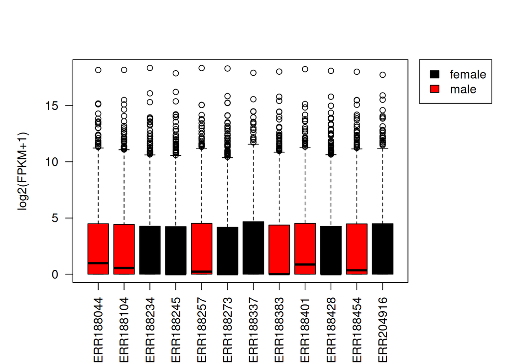

```r
par(mar=c(5.6,5,4.1,7), xpd=TRUE)
fpkm = texpr(bg.data, meas="FPKM")
fpkm = log2(fpkm+1) # add 1 so that basal value is not equal to 0, but when fpkm is 0 then log2 itself is 0.
boxplot(fpkm, col=c(1, 2)[as.numeric(pheno.data$sex)], las = 2, ylab="log2(FPKM+1)", space=0.1)
# legend("topright", legend=c("female", "male"), fill=c("blue", "red"), inset=c(-0.25,0)) # when you wanna add blue, red color to legend
legend("topright", legend=c("female", "male"), fill=c(1,2), inset=c(-0.25, 0))
```

[Boxplot](https://m.blog.naver.com/easternsun/220192315081)

[Legend](https://m.blog.naver.com/liberty264/220977218986)

### 4. Transcript distribution graph for Comparison of Individual Samples

Draw a graph that compares how all the samples are expressing transcripts. First, learn the gene names and transcript names that we’re gonna include in the graph.

```r
ballgown::geneNames(bg.data)[5]
```

```
##        5
## "PLCXD1"
```

```r
ballgown::transcriptNames(bg.data)[5]
```

```
##           5
## "NM_018390"
```

What’s the problem with coercion? It says coercion by NA. Numerical expression error was because of damn colon, instead of double colons. Therefore it was recognizing it as a numerical expression.

Now draw the graph.

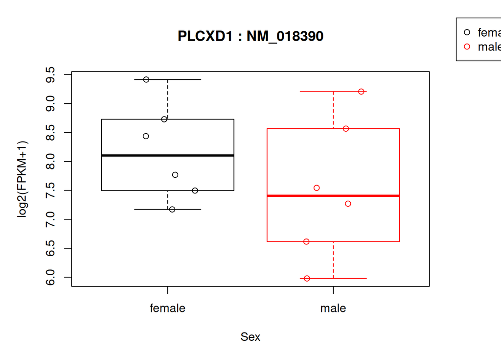

```r
par(mar=c(5,5,5,5), xpd=TRUE)
plot(fpkm[5,]~pheno.data$sex, border=c(1,2), main=paste(ballgown::geneNames(bg.data)[5],":",ballgown::transcriptNames(bg.data)[5]), pch=19, xlab="Sex", ylab="log2(FPKM+1)")
points(fpkm[5,]~jitter(as.numeric(pheno.data$sex)), col=as.numeric(pheno.data$sex))
legend("topright", legend=c("female", "male"), col=c(1,2), inset=c(-0.25, -0.25), pch=c(1,1))
```

*mar* changes margins, *xpd* changes whether there will be elements outside the plot region onto figure region.

This prints all samples’ log2(FPKM+1) (expression level) of gene PLCXD1’s transcript NM_018390 differing by sex.

### 5. Draw all the Transcripts’ Expression Level and Structure on the Same Loci

So let’s draw the graph that gives us all the transcripts’ structure and expression level located on the same loci within a sample. XIST gene is one of the genes known as being expressed more in female than male.

Find out the index of XIST in bg.data, which is the ballgown data class that we imported earlier.

```r
ballgown::geneNames(bg.data)[ballgown::geneNames(bg.data)=="XIST"]
```

```
##   1671
## "XIST"
```

You can do it like regular indexing in a data.frame.

Now print the graph using `plotTranscripts` of ballgown package.

Usage goes like this:

```
plotTranscripts(gene='XLOC_000454', gown=bg, samples='sample12',
    meas='FPKM', colorby='transcript',
    main='transcripts from gene XLOC_000454: sample 12, FPKM')
```

, whereas *gene* is gene, *gown* is the ballgown class data, *main* identifies the title, and sample is identified by *sample*.

The point of this plot is finding out which genomic position is expressed a lot and which position is less expressed respectively.

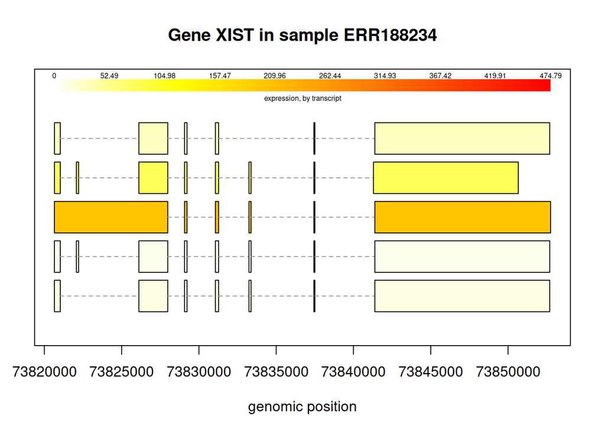

```r
plotTranscripts(ballgown::geneIDs(bg.data)[1671], bg.data, main=c("Gene XIST in sample ERR188234"), sample=c("ERR188234"))
```

You can observe how various transcripts of XIST are distributed in the sample ERR188234.

Tip: You can view a package’s manual with `browseVignettes`. ex.) `browseVignettes("ballgown")`

To find out the mean XIST expression level of both male and female groups, you gotta use plotMeans function. It takes geneID as the input. Find out XIST’s geneID with `ballgown::geneIDs`.

```r
ballgown::geneIDs(bg.data)[1671]
```

```
##        1671
## "MSTRG.535"
```

The geneID is MSTRG.535. Now print the plot with `plotMeans`.

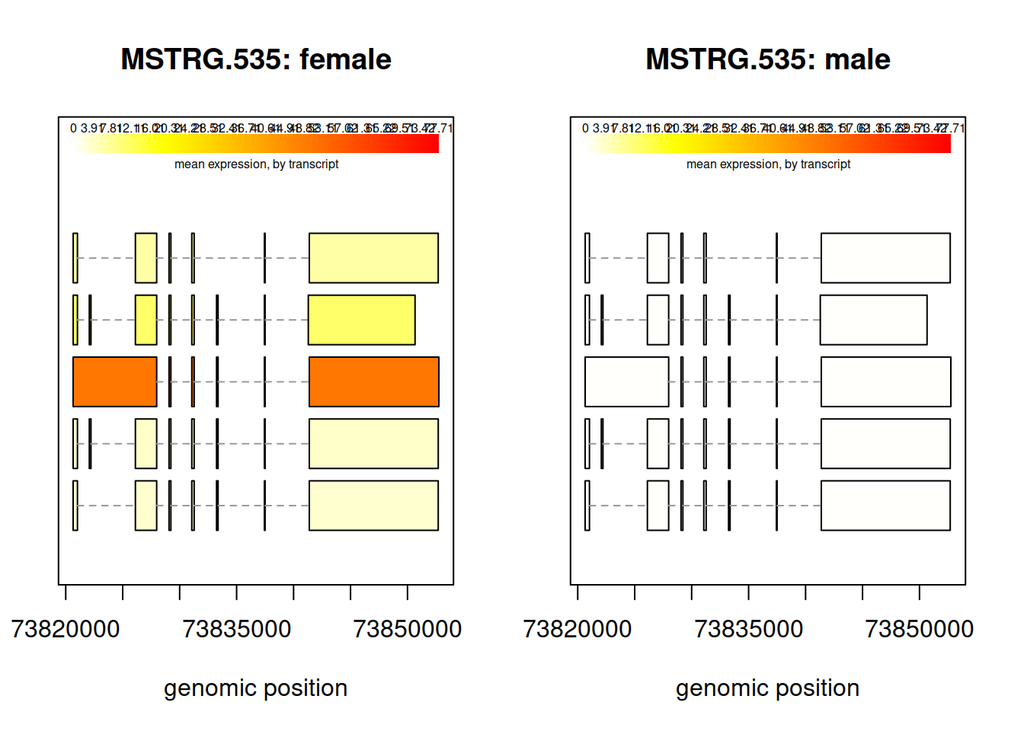

```r
plotMeans("MSTRG.535", bg.data, groupvar="sex", legend=TRUE)
```

### 6. Draw MA graph

Draw the MA plot of the transcripts that show statistically significant results. An MA plot is an pplication of a Bland-Altman plot for visual representation of genomic data. Now, a Bland-Altman plot itself has a second name, difference plot. It’s a method of data plotting used in analyzing the agreement between two different assays or samples. The plot visualizes the differences between measurements taken in two samples, by transforming the data onto M (log ratio) and A (mean average) scales, then plotting these values. Though originally applied in the context of two channel DNA microarray gene expression data, MA plots are also used to visualize high-throughput sequencing analysis.

```r
results.transcripts$mean <- rowMeans(texpr(bg.filt))
```

To explain the below ggplot argument, we have to looks at usage:

You supply a dataset into a `ggplot()` and provide aesthetic mapping with `aes()`. You then add on layers like `geom_point()` or `geom_histogram()`, scales like `scale_colour_brewer()`, faceting specifications like `facet_wrap()` and coordinate systems like `coord_flip()`.

It goes along with something like this:

```
library(ggplot2)
ggplot(mpg, aes(displ, hwy, colour = class)) + geom_point()
```

Let’s play out this example.

```r
library(ggplot2)
data("mtcars")
```

```r
mpg
```

```
## # A tibble: 234 x 11
##    manufacturer model    displ  year   cyl trans   drv     cty   hwy fl    class
##    <chr>        <chr>    <dbl> <int> <int> <chr>   <chr> <int> <int> <chr> <chr>
##  1 audi         a4         1.8  1999     4 auto(l… f        18    29 p     comp…
##  2 audi         a4         1.8  1999     4 manual… f        21    29 p     comp…
##  3 audi         a4         2    2008     4 manual… f        20    31 p     comp…
##  4 audi         a4         2    2008     4 auto(a… f        21    30 p     comp…
##  5 audi         a4         2.8  1999     6 auto(l… f        16    26 p     comp…
##  6 audi         a4         2.8  1999     6 manual… f        18    26 p     comp…
##  7 audi         a4         3.1  2008     6 auto(a… f        18    27 p     comp…
##  8 audi         a4 quat…   1.8  1999     4 manual… 4        18    26 p     comp…
##  9 audi         a4 quat…   1.8  1999     4 auto(l… 4        16    25 p     comp…
## 10 audi         a4 quat…   2    2008     4 manual… 4        20    28 p     comp…
## # … with 224 more rows
```

```r
mpg$displ
```

```
##   [1] 1.8 1.8 2.0 2.0 2.8 2.8 3.1 1.8 1.8 2.0 2.0 2.8 2.8 3.1 3.1 2.8 3.1 4.2
##  [19] 5.3 5.3 5.3 5.7 6.0 5.7 5.7 6.2 6.2 7.0 5.3 5.3 5.7 6.5 2.4 2.4 3.1 3.5
##  [37] 3.6 2.4 3.0 3.3 3.3 3.3 3.3 3.3 3.8 3.8 3.8 4.0 3.7 3.7 3.9 3.9 4.7 4.7
##  [55] 4.7 5.2 5.2 3.9 4.7 4.7 4.7 5.2 5.7 5.9 4.7 4.7 4.7 4.7 4.7 4.7 5.2 5.2
##  [73] 5.7 5.9 4.6 5.4 5.4 4.0 4.0 4.0 4.0 4.6 5.0 4.2 4.2 4.6 4.6 4.6 5.4 5.4
##  [91] 3.8 3.8 4.0 4.0 4.6 4.6 4.6 4.6 5.4 1.6 1.6 1.6 1.6 1.6 1.8 1.8 1.8 2.0
## [109] 2.4 2.4 2.4 2.4 2.5 2.5 3.3 2.0 2.0 2.0 2.0 2.7 2.7 2.7 3.0 3.7 4.0 4.7
## [127] 4.7 4.7 5.7 6.1 4.0 4.2 4.4 4.6 5.4 5.4 5.4 4.0 4.0 4.6 5.0 2.4 2.4 2.5
## [145] 2.5 3.5 3.5 3.0 3.0 3.5 3.3 3.3 4.0 5.6 3.1 3.8 3.8 3.8 5.3 2.5 2.5 2.5
## [163] 2.5 2.5 2.5 2.2 2.2 2.5 2.5 2.5 2.5 2.5 2.5 2.7 2.7 3.4 3.4 4.0 4.7 2.2
## [181] 2.2 2.4 2.4 3.0 3.0 3.5 2.2 2.2 2.4 2.4 3.0 3.0 3.3 1.8 1.8 1.8 1.8 1.8
## [199] 4.7 5.7 2.7 2.7 2.7 3.4 3.4 4.0 4.0 2.0 2.0 2.0 2.0 2.8 1.9 2.0 2.0 2.0
## [217] 2.0 2.5 2.5 2.8 2.8 1.9 1.9 2.0 2.0 2.5 2.5 1.8 1.8 2.0 2.0 2.8 2.8 3.6
```

```r
mpg$hwy
```

```
##   [1] 29 29 31 30 26 26 27 26 25 28 27 25 25 25 25 24 25 23 20 15 20 17 17 26 23
##  [26] 26 25 24 19 14 15 17 27 30 26 29 26 24 24 22 22 24 24 17 22 21 23 23 19 18
##  [51] 17 17 19 19 12 17 15 17 17 12 17 16 18 15 16 12 17 17 16 12 15 16 17 15 17
##  [76] 17 18 17 19 17 19 19 17 17 17 16 16 17 15 17 26 25 26 24 21 22 23 22 20 33
## [101] 32 32 29 32 34 36 36 29 26 27 30 31 26 26 28 26 29 28 27 24 24 24 22 19 20
## [126] 17 12 19 18 14 15 18 18 15 17 16 18 17 19 19 17 29 27 31 32 27 26 26 25 25
## [151] 17 17 20 18 26 26 27 28 25 25 24 27 25 26 23 26 26 26 26 25 27 25 27 20 20
## [176] 19 17 20 17 29 27 31 31 26 26 28 27 29 31 31 26 26 27 30 33 35 37 35 15 18
## [201] 20 20 22 17 19 18 20 29 26 29 29 24 44 29 26 29 29 29 29 23 24 44 41 29 26
## [226] 28 29 29 29 28 29 26 26 26
```

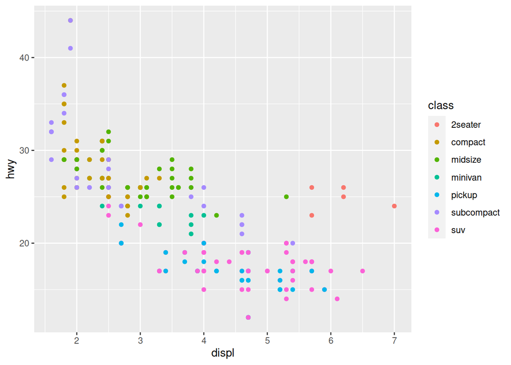

```r
ggplot(mpg, aes(displ, hwy, colour = class)) + geom_point()
```

Like above, you provide `ggplot()` with a dataset, aesthetic mapping of x value and y value, color mapping. And then add layers onto that to add more details, for example `scale_color_manual()`, a geom function like `geom_point()`, and/or additional features like `geom_hline(yintercept=0)`. For more information about ggplot2 refer to [this link](https://apple-rbox.tistory.com/13) and [this official website on ggplot2](https://ggplot2.tidyverse.org/)

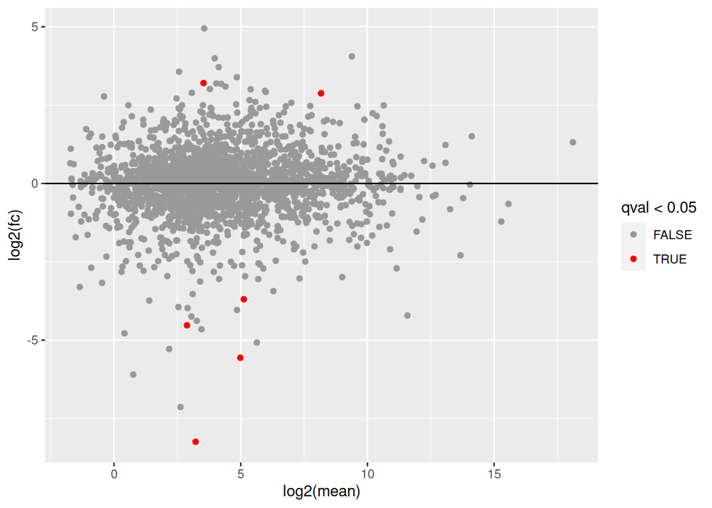

```r
ggplot(results.transcripts, aes(log2(mean), log2(fc), colour=qval<0.05)) + scale_color_manual(values=c("#999999", "#FF0000")) + geom_point() + geom_hline(yintercept=0)
```

MA plot that indicates transcripts that have q-value of under 0.05 only as red dots.

# IV. Exploring Differentially Expressed Genes with DEGseq

Use DEGseq to perform TCGA data analysis. First, run R and load DEGseq library.

```r
library(DEGseq)
```

```r
dir(pattern = "TCGA_BRCA*")
```

```
## [1] "TCGA_BRCA_Sample.txt"
```

`TCGA_BRCA_Sample.txt` file has RPKM values (normalized expression value over genes and over samples) for genes for each sample.

```r
geneExpMatrix1 <- readGeneExp(file = "TCGA_BRCA_Sample.txt", geneCol=1, valCol=c(2:11))
geneExpMatrix2 <- readGeneExp(file = "TCGA_BRCA_Sample.txt", geneCol=1, valCol=c(12:21))
```

Divide the TCGA_BRCA_Sample.txt into cancer sample gene expression matrix and normal sample gene expression matrix.

```r
head(geneExpMatrix1) # This pertains to Cancer samples 1 through 10.
```

```
##           Gene        Cancer1          Cancer2          Cancer3
## ARHGEF10L "ARHGEF10L" "7.10459082235"  "7.30186439022"  "10.4262448958"
## HIF3A     "HIF3A"     "0.477700346119" "0.337062632081" "0.892586526484"
## RNF17     "RNF17"     "0"              "0"              "0"
## RNF10     "RNF10"     "46.8800026251"  "42.5777343851"  "36.1966704884"
## RNF11     "RNF11"     "30.0654551153"  "42.4993747157"  "75.6563622111"
## RNF13     "RNF13"     "24.4071301974"  "24.2848664147"  "38.4074326478"
##           Cancer4         Cancer5          Cancer6
## ARHGEF10L "6.25069164335" "4.97189834949"  "7.59780256411"
## HIF3A     "0.57943952058" "0.765271558729" "0.721413882277"
## RNF17     "0"             "0"              "0.00186201894835"
## RNF10     "55.6552318137" "48.8053421191"  "47.3575567479"
## RNF11     "33.5551142837" "24.3952092625"  "37.0648223589"
## RNF13     "17.297747402"  "19.5296830693"  "22.6162785594"
##           Cancer7            Cancer8           Cancer9
## ARHGEF10L "5.75649586108"    "2.81436133579"   "7.28612963111"
## HIF3A     "0.531417358771"   "0.57526731215"   "0.740608583477"
## RNF17     "0.00412602590251" "0.0661900836316" "0.00667243268065"
## RNF10     "59.4391876114"    "28.6097931927"   "43.2646321945"
## RNF11     "23.2145693219"    "30.1879441349"   "36.034941624"
## RNF13     "16.3314532771"    "34.3156396696"   "23.6265476241"
##           Cancer10
## ARHGEF10L "7.00057286213"
## HIF3A     "0.738899259304"
## RNF17     "0.00417541696601"
## RNF10     "31.4354355111"
## RNF11     "21.6621932781"
## RNF13     "33.520544918"
```

```r
head(geneExpMatrix2) # This pertains to Normal samples 1 through 10.
```

```
##           Gene        Normal1         Normal2         Normal3
## ARHGEF10L "ARHGEF10L" "7.63826725634" "10.8042956583" "12.4165783938"
## HIF3A     "HIF3A"     "10.359389523"  "6.68423155706" "6.96443710384"
## RNF17     "RNF17"     "0"             "0"             "0"
## RNF10     "RNF10"     "33.7806865028" "35.930726213"  "35.6573197613"
## RNF11     "RNF11"     "40.7311351937" "35.1199204296" "44.2800700536"
## RNF13     "RNF13"     "21.1209785968" "26.2989122968" "21.9971771263"
##           Normal4            Normal5            Normal6
## ARHGEF10L "2.90849122613"    "6.3395855811"     "9.08563493277"
## HIF3A     "15.2137996855"    "6.89007500418"    "5.65614264739"
## RNF17     "0.00216335768771" "0.00212394790851" "0"
## RNF10     "29.8918473841"    "29.644713974"     "37.8659641307"
## RNF11     "51.4044362804"    "37.6817964681"    "41.2155136069"
## RNF13     "28.5295904469"    "32.7111480065"    "32.6804277931"
##           Normal7           Normal8         Normal9          Normal10
## ARHGEF10L "9.17622811995"   "10.651566692"  "12.2370583584"  "11.2567873861"
## HIF3A     "2.43605878201"   "4.58560401188" "3.60779966557"  "1.5035264005"
## RNF17     "0.0416850926984" "0"             "0.316111880032" "0"
## RNF10     "37.4595679533"   "37.1360689323" "36.392697784"   "35.9080724825"
## RNF11     "36.3215618224"   "43.2652800127" "41.5055266267"  "38.8747635446"
## RNF13     "21.9840729534"   "26.1122244581" "28.4620264531"  "18.3064978852"
```

Next are functions that perform comparison between two groups. First of all, set the layout of the graph with `layout`: 3 by 2 (row by column) graphs and set the margins between graphs.

```
Usage
layout(mat, widths = rep.int(1, ncol(mat)),
       heights = rep.int(1, nrow(mat)), respect = FALSE)

mat = matrix(c(1,2,3,4,5,6)): a matrix object specifying the location of the next N figures on the output device.

widths, heights = 3, 2

byrow=TRUE: as it is. arrange the multiple figures by row.
```

```r
layout(matrix(c(1,2,3,4,5,6), 3, 2, byrow = TRUE))
par(mar=c(2,2,2,2))
```

**DEGexp**: identifying differentially expressed genes from gene expression data

This function is used to identify differentially expressed genes when users already have the gene expression values (or the number of reads mapped to each gene.)

```r
layout(matrix(c(1,2,3,4,5,6), 3, 2, byrow = TRUE))
par(mar=c(2,2,2,2))
DEGseq::DEGexp(geneExpMatrix1=geneExpMatrix1, geneCol1 = 1, expCol1 = c(2:11), groupLabel1 = "Cancer", geneExpMatrix2=geneExpMatrix2, geneCol2=1, expCol2=c(2:11), groupLabel2 = "Normal", method="MARS")
```

```
## Please wait...
## gene id column in geneExpMatrix1 for sample1:  1
## expression value column(s) in geneExpMatrix1: 2 3 4 5 6 7 8 9 10 11
## total number of reads uniquely mapped to genome obtained from sample1: 16967.8 17351.95 15199.09 16475.55 15148.19 15582.26 15262.71 15490.95 14671.85 15624.94
## gene id column in geneExpMatrix2 for sample2:  1
## expression value column(s) in geneExpMatrix2: 2 3 4 5 6 7 8 9 10 11
## total number of reads uniquely mapped to genome obtained from sample2: 17216.45 17540.92 15951.68 13681.41 15758.46 18140.48 16580.22 17018.78 14756.33 15988.37
##
## method to identify differentially expressed genes:  MARS
## pValue threshold: 0.001
## output directory: none
##
## The outputDir is not specified!
## Please wait ...
```

```
## Identifying differentially expressed genes ...
## Please wait patiently ...
```

```
## output ...
## The results can be observed in directory:  none
```

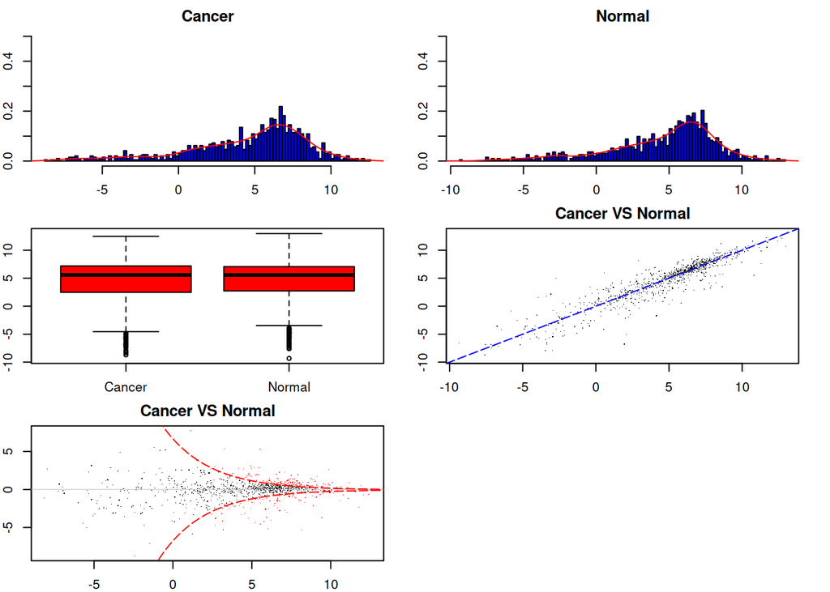

Here we used MARS statistical test. MARS stands for MA-plot-based method with Random Sampling model. Refer to this article called [“Which Statistical Significance Test Best Detects OncomiRNAs in Cancer Tissues?: An Exploratory Analysis”](https://www.oncotarget.com/article/12828/text/) In this study, the authors compared miRNAs obtained from 6 common significance tests/R packages (t-test, Limma, DESeq, edgeR, LRT and MARS)

Let’s do more practice with `DEGexp` from DEGseq [manual](https://bioconductor.org/packages/release/bioc/vignettes/DEGseq/inst/doc/DEGseq.pdf). And more on [RPubs](https://rpubs.com/taslima/222140).

```r
library(DEGseq)
geneExpFile <- system.file("extdata", "GeneExpExample5000.txt", package="DEGseq")
```

```r
geneExpFile
```

```
## [1] "/home/seungho/R/x86_64-pc-linux-gnu-library/3.6/DEGseq/extdata/GeneExpExample5000.txt"
```

It’s got 7 lanes for kidney and 7 lanes for liver.

Take 5 samples’ expression data out of each.

```r
geneExpM1 <- readGeneExp(file=geneExpFile, geneCol=1, valCol=c(7, 9, 12, 15, 18))
geneExpM2 <- readGeneExp(file=geneExpFile, geneCol=1, valCol=c(8, 10, 11, 13, 16))
write.table(geneExpM1[30:31], row.names=FALSE)
```

```
## "x"
## "ENSG00000188976"
## "ENSG00000187961"
```

```r
write.table(geneExpM2[30:31], row.names=FALSE)
```

```
## "x"
## "ENSG00000188976"
## "ENSG00000187961"
```

```r
head(geneExpM1)
```

```
##                 EnsemblGeneID     R1L1Kidney R1L3Kidney R1L7Kidney R2L2Kidney
## ENSG00000146556 "ENSG00000146556" "0"        "0"        "0"        "0"
## ENSG00000197194 "ENSG00000197194" "0"        "0"        "0"        "0"
## ENSG00000197490 "ENSG00000197490" "0"        "0"        "0"        "0"
## ENSG00000205292 "ENSG00000205292" "0"        "0"        "0"        "0"
## ENSG00000177693 "ENSG00000177693" "0"        "0"        "0"        "0"
## ENSG00000209338 "ENSG00000209338" "0"        "0"        "0"        "0"
##                 R2L6Kidney
## ENSG00000146556 "0"
## ENSG00000197194 "0"
## ENSG00000197490 "0"
## ENSG00000205292 "0"
## ENSG00000177693 "0"
## ENSG00000209338 "0"
```

```r
layout(matrix(c(1,2,3,4,5,6), 3, 2, byrow=TRUE))
par(mar=c(2,2,2,2))
DEGexp(geneExpMatrix1= geneExpM1, geneCol1=1, expCol1=c(2, 3, 4, 5, 6), groupLabel1="kidney", geneExpMatrix2= geneExpM2, geneCol2=1, expCol2=c(2,3,4,5,6), groupLabel2="liver", method="MARS")
```

```
## Please wait...
## gene id column in geneExpMatrix1 for sample1:  1
## expression value column(s) in geneExpMatrix1: 2 3 4 5 6
## total number of reads uniquely mapped to genome obtained from sample1: 345504 354981 334557 366041 372895
## gene id column in geneExpMatrix2 for sample2:  1
## expression value column(s) in geneExpMatrix2: 2 3 4 5 6
## total number of reads uniquely mapped to genome obtained from sample2: 274430 274486 264999 255041 284205
##
## method to identify differentially expressed genes:  MARS
## pValue threshold: 0.001
## output directory: none
##
## The outputDir is not specified!
## Please wait ...
```

```
## Identifying differentially expressed genes ...
## Please wait patiently ...
```

```
## output ...
## The results can be observed in directory:  none
```

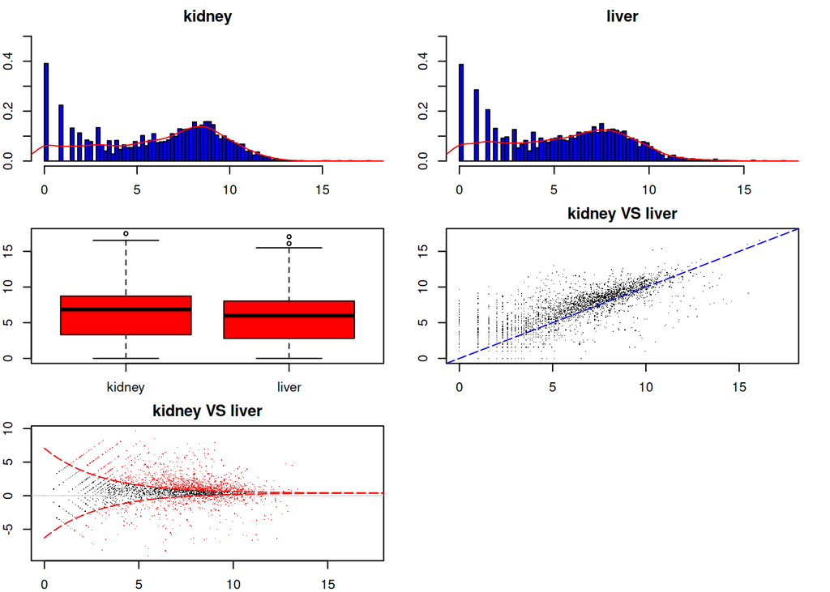

## Boxplot

Let’s boxplot on each replicates of two tissue to see the distribution of count data in log2 scale.

```r
library(reshape2)
library(ggplot2)
```

```r
geneExpMatrixMerge <- merge(geneExpM1, geneExpM2, by = "EnsemblGeneID")
```

```r
head(geneExpMatrixMerge, 5)
```

```
##     EnsemblGeneID R1L1Kidney R1L3Kidney R1L7Kidney R2L2Kidney R2L6Kidney
## 1 ENSG00000000457         22         33         30         27         30
## 2 ENSG00000000460          9          7         18         14          9
## 3 ENSG00000000938         14         18          7         27         15
## 4 ENSG00000000971         28         27         28         34         42
## 5 ENSG00000001460         24         29         30         31         23
##   R1L2Liver R1L4Liver R1L6Liver R1L8Liver R2L3Liver
## 1        47        60        37        42        62
## 2        19         9        13        14        19
## 3        42        34        39        37        45
## 4       470       502       500       490       536
## 5         4         5         3         6         4
```

```r
df <- melt(geneExpMatrixMerge, id.vars = "EnsemblGeneID", variable.name = "Samples", value.name = "count")
df[, "count"] <- as.numeric(df[, "count"])
head(df)
```

```
##     EnsemblGeneID    Samples count
## 1 ENSG00000000457 R1L1Kidney    22
## 2 ENSG00000000460 R1L1Kidney     9
## 3 ENSG00000000938 R1L1Kidney    14
## 4 ENSG00000000971 R1L1Kidney    28
## 5 ENSG00000001460 R1L1Kidney    24
## 6 ENSG00000001461 R1L1Kidney    23
```

```r
tail(df)
```

```
##         EnsemblGeneID   Samples count
## 49995 ENSG00000216157 R2L3Liver     0
## 49996 ENSG00000216161 R2L3Liver     0
## 49997 ENSG00000216162 R2L3Liver     0
## 49998 ENSG00000216186 R2L3Liver     0
## 49999 ENSG00000216191 R2L3Liver     0
## 50000 ENSG00000216193 R2L3Liver     0
```

```r
df$Condition <- substr(df$Samples, 5, nchar(toString(df$Samples[1])))
head(df)
```

```
##     EnsemblGeneID    Samples count Condition
## 1 ENSG00000000457 R1L1Kidney    22    Kidney
## 2 ENSG00000000460 R1L1Kidney     9    Kidney
## 3 ENSG00000000938 R1L1Kidney    14    Kidney
## 4 ENSG00000000971 R1L1Kidney    28    Kidney
## 5 ENSG00000001460 R1L1Kidney    24    Kidney
## 6 ENSG00000001461 R1L1Kidney    23    Kidney
```

Base function **`substr()`** and **`str_sub()`** of stringr package are the most commonly used functions for extracting substrings. `substr(df$Samples, 5, length(df$Samples))` means "take the column df$Samples, which is a column made of characters, and only extract the letters beginning from index 5 to the end of the string (`nchar(toString(df\$Samples[1]`))).

```
## Warning: Removed 22043 rows containing non-finite values (stat_boxplot).
```

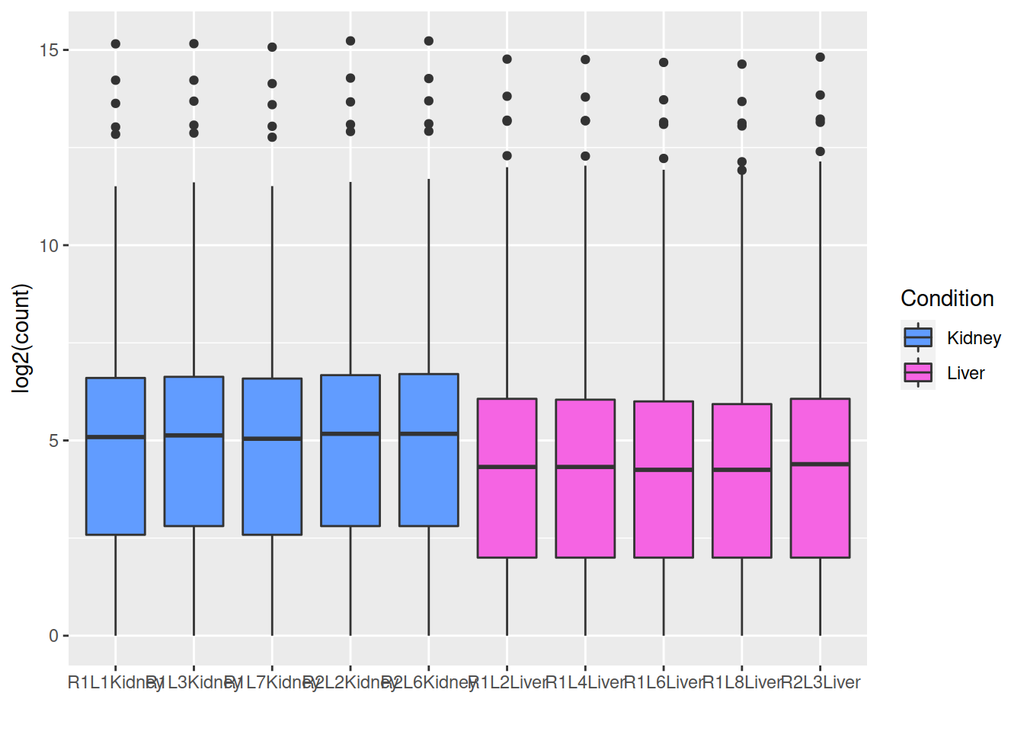

```r
ggplot(df, aes(x = Samples, y = log2(count), fill=Condition)) + geom_boxplot() + xlab("") + ylab("log2(count)") +scale_fill_manual(values = c("#619CFF", "#F564E3"))
```

There’s a warning message “Removed 22043 rows containing non-finite values (stat_boxplot)” and this is due to NA values being excluded in the `ggplot()` (Refer to [Investigate Cause of ‘Removed N rows containing non-finite values (stat_count)’ in ggplots](https://github.com/mjhendrickson/Learning-R/issues/2)). So we gotta consider `!is.na()` or try piping `%>%` and feeding NA handling into `ggplot()`.

```r
head(log2(df$count), 100)
```

```
##   [1]  4.459432  3.169925  3.807355  4.807355  4.584963  4.523562  5.614710
##   [8]  6.339850  5.857981  7.000000  6.658211  4.700440  5.700440  6.741467
##  [15]  5.807355  3.321928  2.584963  6.584963  4.169925  4.247928  7.942515
##  [22]  4.754888      -Inf  3.584963  5.643856  6.303781  6.882643 10.348728
##  [29]      -Inf  3.321928  4.700440  4.169925  3.321928  5.754888  6.459432
##  [36]  7.930737  6.108524  4.584963  4.392317  6.209453  6.930737  8.082149
##  [43]  7.417853  9.245553  4.857981      -Inf  0.000000      -Inf  6.375039
##  [50]  4.857981  4.906891  0.000000  5.807355  1.584963  4.857981  5.906891
##  [57]  3.321928  8.679480  4.392317  5.044394  5.000000      -Inf  8.361944
##  [64]  0.000000  5.209453  0.000000  5.000000  4.392317  1.000000  7.475733
##  [71]  5.554589      -Inf  8.682995  2.584963  8.487840  6.658211  6.629357
##  [78]  6.129283  5.807355  4.169925  5.087463  4.392317  7.442943  7.199672
##  [85]      -Inf  5.209453      -Inf  7.400879  8.581201  6.169925  4.754888
##  [92]  7.515700  7.189825  6.554589      -Inf      -Inf  1.584963  6.882643
##  [99]  7.159871      -Inf
```

Actually, this wasn’t the case. Rather, it was because of expression values exhibiting 0 and when they are passed onto log2, they suddenly have `-Inf`. This is why there was a warning about non-finite values.

So, remove what **isn’t** finite.

```
## Warning: Removed 22043 rows containing non-finite values (stat_boxplot).
```

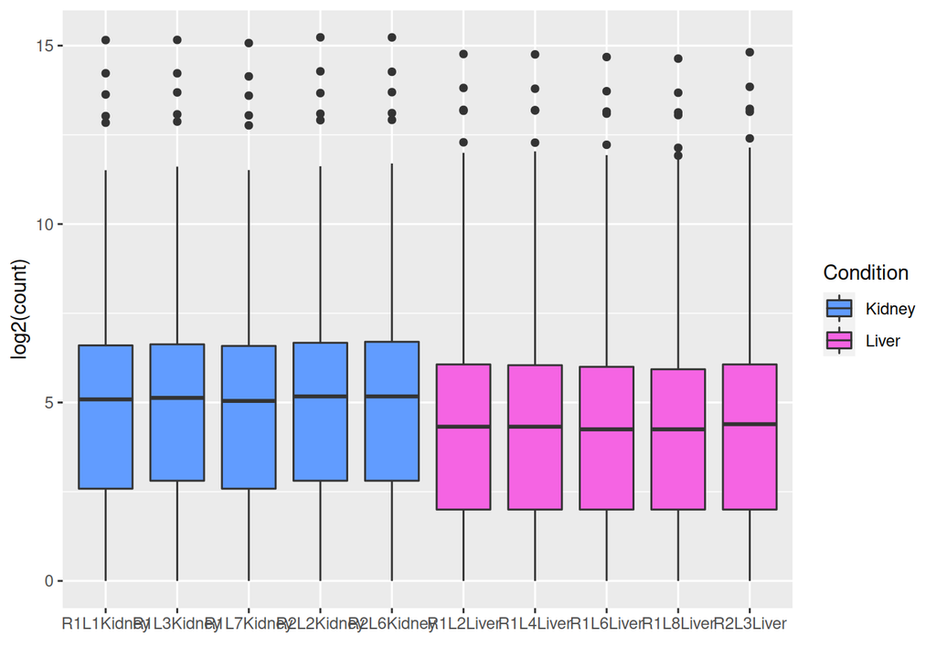

```r
ggplot(df, aes(x = Samples[is.finite(count)], y = log2(count[is.finite(count)]), fill=Condition)) + geom_boxplot() + xlab("") + ylab("log2(count)") +scale_fill_manual(values = c("#619CFF", "#F564E3"))
```

## Assumption

RNA sequencing can be modeled as a random sampling process, in which each read is sampled independently and uniformly from every possible nucleotide in the sample.

## Model

Under this assumption the number of reads coming from a gene (or transcript isoform) follows a binomial distribution (and could be approximated by a Poisson distribution) (Wang et al, 2010).

## MA-plot-based method

MA plot is basically log fold change vs. log average of a gene for two different samples/replicates.

Let C1 and C2 denote the counts of reads mapped to a specific gene obtained from two samples, with Ci ~ binomial(ni, pi), i = 1, 2, where ni denotes the total number of mapped reads and pi the probability of a read coming from that gene. Then $M = log_2C_1-log_2C_2$, and $A=(log2C1+log2C2)/2$ It can be proved that under the random sampling assumption the conditoinal distribution of $M$ given that $A=a$ ($a$ is an observation of $A$), follows an approximate normal distribution. For each gene on the MA-plot, we do the hypothesis test of $H_0: \textrm{p}_1=\textrm{p}_2$ versus $H_1: \textrm{p}_1\ne\textrm{p}_2$. Then a p-value could be assigned based on the conditional normal distribution.

```
# M = log2C1 - log2C2, and A = (log2C1 + log2C2)/2
```

### Differentially Expressed Gene Analysis

#### Step 1: MARS (MA-plot-based method with Random Sampling model)

We will fit a simple random sampling model to get the DEGs and will see the effect. The red line of the MA-plot indicates 4-fold local Standard Deviation of M conditioned on A for two samples.

`method`: method to identify differentially expressed genes. Possible methods are: - “LRT”: Likelihood Ratio Test (Marioni et al. 2008) - “CTR”: Check whether the variation between Technical Replicates can beexplained by the random sampling model (Wang et al. 2009) - “FET”: Fisher’s Exact Test (Joshua et al. 2009) - “MARS”: MA-plot-based method with Random Sampling model (Wang etal. 2009) - “MATR”: MA-plot-based method with Technical Replicates (Wang et al.2009) - “FC”: Fold-Change threshold on MA-plot.

```r
layout(matrix(c(1,2,3,4,5,6), 3, 2, byrow=TRUE))
par(mar=c(2, 2, 2, 2))
DEGexp(geneExpMatrix1 = geneExpM1, geneCol1=1, expCol1=c(2,3,4,5,6), groupLabel1="kidney", geneExpMatrix2=geneExpM2, geneCol2=1, expCol2=c(2,3,4,5,6), groupLabel2="liver", method="MARS")
```

```
## Please wait...
## gene id column in geneExpMatrix1 for sample1:  1
## expression value column(s) in geneExpMatrix1: 2 3 4 5 6
## total number of reads uniquely mapped to genome obtained from sample1: 345504 354981 334557 366041 372895
## gene id column in geneExpMatrix2 for sample2:  1
## expression value column(s) in geneExpMatrix2: 2 3 4 5 6
## total number of reads uniquely mapped to genome obtained from sample2: 274430 274486 264999 255041 284205
##
## method to identify differentially expressed genes:  MARS
## pValue threshold: 0.001
## output directory: none
##
## The outputDir is not specified!
## Please wait ...
```

```
## Identifying differentially expressed genes ...
## Please wait patiently ...
```

```
## output ...
## The results can be observed in directory:  none
```

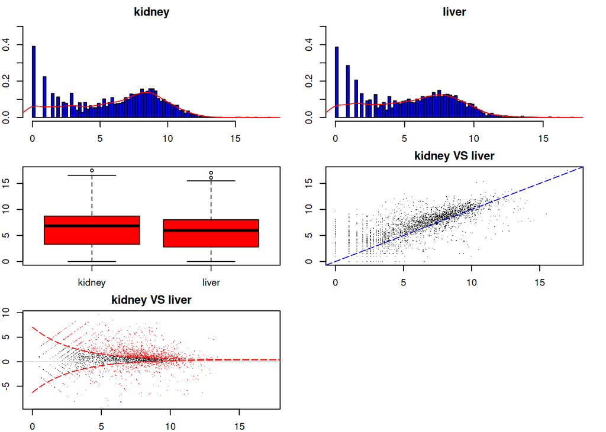

#### Step 2: CTR (Check whether the variation between Technical Replicates)

Now we will check how the technical replicates go with each other. Can two technical replicates alone explain the random sampling model? Is there any background noise for two technical replicates?

Let’s try it for liver…

```r
head(geneExpM2)
```

```
##                 EnsemblGeneID     R1L2Liver R1L4Liver R1L6Liver R1L8Liver
## ENSG00000146556 "ENSG00000146556" "0"       "0"       "0"       "0"
## ENSG00000197194 "ENSG00000197194" "0"       "0"       "0"       "0"
## ENSG00000197490 "ENSG00000197490" "0"       "0"       "0"       "0"
## ENSG00000205292 "ENSG00000205292" "0"       "0"       "0"       "0"
## ENSG00000177693 "ENSG00000177693" "0"       "0"       "0"       "0"
## ENSG00000209338 "ENSG00000209338" "0"       "0"       "0"       "0"
##                 R2L3Liver
## ENSG00000146556 "0"
## ENSG00000197194 "0"
## ENSG00000197490 "0"
## ENSG00000205292 "0"
## ENSG00000177693 "0"
## ENSG00000209338 "0"
```

```r
layout(matrix(c(1,2,3,4,5,6), 3, 2, byrow=TRUE))
par(mar=c(2,2,2,2))
DEGexp(geneExpMatrix1 = geneExpM2, expCol1=2, groupLabel1= "LiverR1L2", geneExpMatrix2 = geneExpM2, expCol2=3, groupLabel2="LiverR1L4", method="CTR")
```

```
## Please wait...
## gene id column in geneExpMatrix1 for sample1:  1
## expression value column(s) in geneExpMatrix1: 2
## total number of reads uniquely mapped to genome obtained from sample1: 274430
## gene id column in geneExpMatrix2 for sample2:  1
## expression value column(s) in geneExpMatrix2: 3
## total number of reads uniquely mapped to genome obtained from sample2: 274486
##
## method to identify differentially expressed genes:  CTR
## pValue threshold: 0.001
## output directory: none
##
## The outputDir is not specified!
## Please wait ...
```

```
## Identifying differentially expressed genes ...
## Please wait patiently ...
```

```
## output ...
## The results can be observed in directory:  none
```

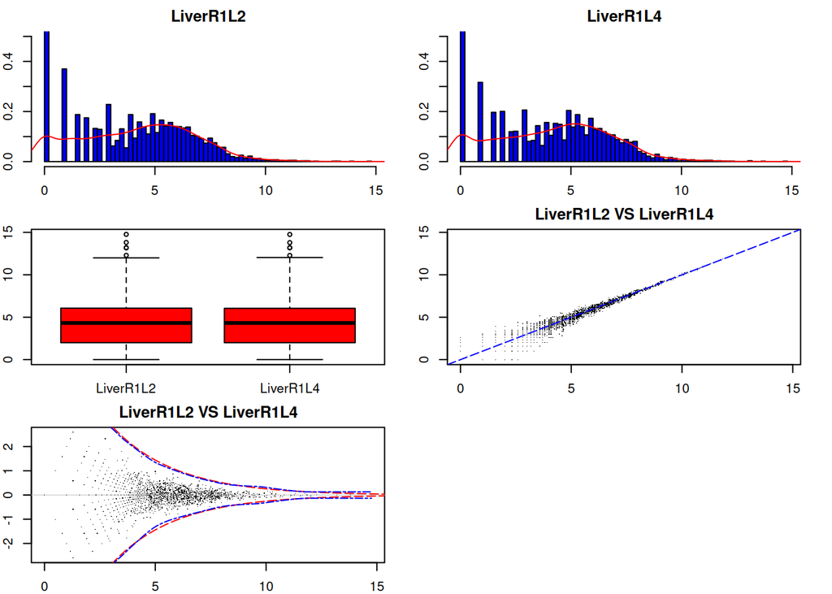

Explanation:

[figure not shown]

[^2]

Can we do the same for 1st and 3rd expression columns of Kidney data?

```r
head(geneExpM1)
```

```
##                 EnsemblGeneID     R1L1Kidney R1L3Kidney R1L7Kidney R2L2Kidney
## ENSG00000146556 "ENSG00000146556" "0"        "0"        "0"        "0"
## ENSG00000197194 "ENSG00000197194" "0"        "0"        "0"        "0"
## ENSG00000197490 "ENSG00000197490" "0"        "0"        "0"        "0"
## ENSG00000205292 "ENSG00000205292" "0"        "0"        "0"        "0"
## ENSG00000177693 "ENSG00000177693" "0"        "0"        "0"        "0"
## ENSG00000209338 "ENSG00000209338" "0"        "0"        "0"        "0"
##                 R2L6Kidney
## ENSG00000146556 "0"
## ENSG00000197194 "0"
## ENSG00000197490 "0"
## ENSG00000205292 "0"
## ENSG00000177693 "0"
## ENSG00000209338 "0"
```

```r
layout(matrix(c(1,2,3,4,5,6), 3, 2, byrow=TRUE))
par(mar=c(2,2,2,2))
DEGexp(geneExpMatrix1=geneExpM1, expCol1=2, groupLabel1= "R1L1Kidney", geneExpMatrix2=geneExpM1, expCol2=4, groupLabel2="R1L7Kidney", method="CTR")
```

```
## Please wait...
## gene id column in geneExpMatrix1 for sample1:  1
## expression value column(s) in geneExpMatrix1: 2
## total number of reads uniquely mapped to genome obtained from sample1: 345504
## gene id column in geneExpMatrix2 for sample2:  1
## expression value column(s) in geneExpMatrix2: 4
## total number of reads uniquely mapped to genome obtained from sample2: 334557
##
## method to identify differentially expressed genes:  CTR
## pValue threshold: 0.001
## output directory: none
##
## The outputDir is not specified!
## Please wait ...
```

```
## Identifying differentially expressed genes ...
## Please wait patiently ...
```

```
## output ...
## The results can be observed in directory:  none
```

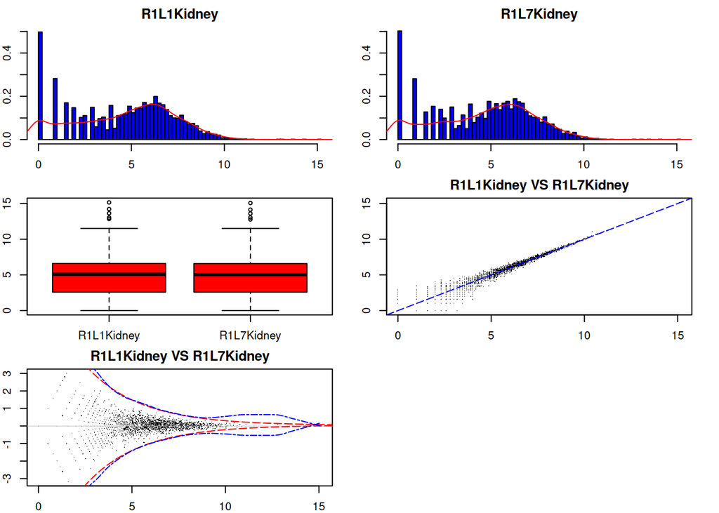

#### Step 3A: MATR (MA-plot-based method with Technical Replicates)

When we need to normalize technical replicates… (the replicates themselves)

```r
layout(matrix(c(1,2,3,4,5,6), 3, 2, byrow=TRUE))
par(mar=c(2,2,2,2))
DEGexp(geneExpMatrix1=geneExpM1, expCol1=2, groupLabel1="R1L1Kidney", geneExpMatrix2=geneExpM2, expCol2=2, groupLabel2="R1L2Liver", replicateExpMatrix1=geneExpM2, expColR1=2, replicateExpMatrix2=geneExpM1, expColR2=3, replicateLabel2="kidneyR1L3", method="MATR")
```

```
## Please wait...
## gene id column in geneExpMatrix1 for sample1:  1
## expression value column(s) in geneExpMatrix1: 2
## total number of reads uniquely mapped to genome obtained from sample1: 345504
## gene id column in geneExpMatrix2 for sample2:  1
## expression value column(s) in geneExpMatrix2: 2
## total number of reads uniquely mapped to genome obtained from sample2: 274430
##
## gene id column in replicateExpMatrix1:  1
## expression value column(s) in replicateExpMatrix1: 2
## total number of reads uniquely mapped to genome obtained from replicate1: 274430
##
## gene id column in replicateExpMatrix2:  1
## expression value column(s) in replicateExpMatrix2: 3
## total number of reads uniquely mapped to genome obtained from replicate2: 354981
##
## method to identify differentially expressed genes:  MATR
## pValue threshold: 0.001
## output directory: none
##
## The outputDir is not specified!
## Please wait ...
```

```
## Identifying differentially expressed genes ...
## Please wait patiently ...
```

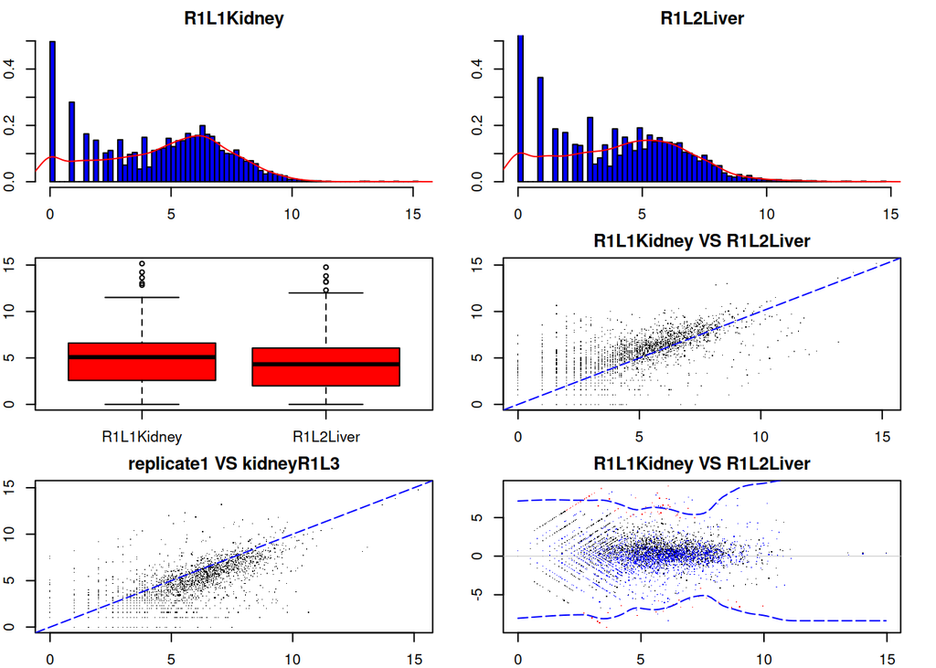

```
## output ...
## The results can be observed in directory:  none
```

#### Step 3B: LRT (Likelihood Ratio Test)

```r
outputDir <- file.path(getwd(), "DEGexpExample")
```

Make DEGexpExample directory.

```r
layout(matrix(c(1,2,3,4,5,6), 3, 2, byrow=TRUE))
par(mar=c(2,2,2,2))
DEGexp(geneExpMatrix1=geneExpM1, geneCol1=1, expCol1=c(2,3,4,5,6), groupLabel1="kidney", geneExpMatrix2=geneExpM2, geneCol2=1, expCol2=c(2,3,4,5,6), groupLabel2="liver", method="LRT")
```

```
## Please wait...
## gene id column in geneExpMatrix1 for sample1:  1
## expression value column(s) in geneExpMatrix1: 2 3 4 5 6
## total number of reads uniquely mapped to genome obtained from sample1: 345504 354981 334557 366041 372895
## gene id column in geneExpMatrix2 for sample2:  1
## expression value column(s) in geneExpMatrix2: 2 3 4 5 6
## total number of reads uniquely mapped to genome obtained from sample2: 274430 274486 264999 255041 284205
##
## method to identify differentially expressed genes:  LRT
## pValue threshold: 0.001
## output directory: none
##
## The outputDir is not specified!
## Please wait ...
```

```
## Identifying differentially expressed genes ...
## Please wait patiently ...
```

```
## output ...
## The results can be observed in directory:  none
```

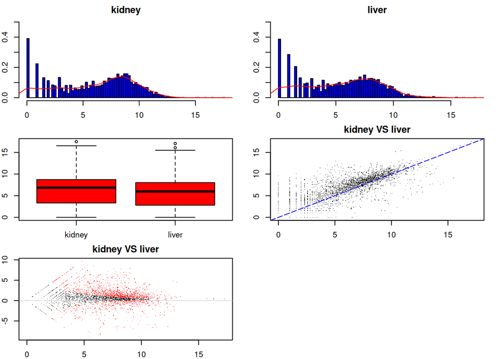

If you want to output these files into outputDir, just type that in as an arugument of function `DEGexp()`.

```r
layout(matrix(c(1,2,3,4,5,6), 3, 2, byrow=TRUE))
par(mar=c(2,2,2,2))
DEGexp(geneExpMatrix1=geneExpM1, geneCol1=1, expCol1=c(2,3,4,5,6), groupLabel1="kidney", geneExpMatrix2=geneExpM2, geneCol2=1, expCol2=c(2,3,4,5,6), groupLabel2="liver", method="LRT", outputDir=outputDir) # Added outputDir
```

```
## Please wait...
## gene id column in geneExpMatrix1 for sample1:  1
## expression value column(s) in geneExpMatrix1: 2 3 4 5 6
## total number of reads uniquely mapped to genome obtained from sample1: 345504 354981 334557 366041 372895
## gene id column in geneExpMatrix2 for sample2:  1
## expression value column(s) in geneExpMatrix2: 2 3 4 5 6
## total number of reads uniquely mapped to genome obtained from sample2: 274430 274486 264999 255041 284205
##
## method to identify differentially expressed genes:  LRT
## pValue threshold: 0.001
## output directory: /home/seungho/GDA/RNAPreprocess/DEGexpExample
##
## Please wait ...
```

```
## Identifying differentially expressed genes ...
## Please wait patiently ...
```

```
## output ...
##
## Done ...
## The results can be observed in directory:  /home/seungho/GDA/RNAPreprocess/DEGexpExample
```

### Working with output DEGs

If we mention output directory for DEGexp function, then it will write the results in that directory and we can use them to get DEGs in different fold range or direction (up/downregulated). The result is actually a list of all genes with their test statistics. The last column indicate its significance: TRUE/FALSE (p-value < 0.001)

```r
result <- read.table(file=file.path(outputDir, "output_score.txt"), header = T, sep = "\t")
```

```r
head(result,5)
```

```
##         GeneNames value1 value2 log2.Fold_change. log2.Fold_change..normalized
## 1 ENSG00000209350     27    161        -2.5760294                   -2.9666840
## 2 ENSG00000212679    620    746        -0.2669074                   -0.6575620
## 3 ENSG00000212678  64591  44870         0.5255820                    0.1349274
## 4 ENSG00000188157   2108    259         3.0248509                    2.6341962
## 5 ENSG00000008130    425    836        -0.9760401                   -1.3666947
##   p.value q.value.Benjamini.et.al..1995. q.value.Storey.et.al..2003.
## 1       0                              0                           0
## 2       0                              0                           0
## 3       0                              0                           0
## 4       0                              0                           0
## 5       0                              0                           0
##   Signature.p.value...0.001.
## 1                       TRUE
## 2                       TRUE
## 3                       TRUE
## 4                       TRUE
## 5                       TRUE
```

```r
colnames(result) <- c("GeneNames", "value1", "value2", "log2_Fold_change", "log2_Fold_change_normalized", "pval", "qval1", "qval2", "Signature")
```

Benjamini definition of q-value (adjusted p-value) and Storey definition of q-value must be different.

```r
head(result)
```

```
##         GeneNames value1 value2 log2_Fold_change log2_Fold_change_normalized
## 1 ENSG00000209350     27    161       -2.5760294                  -2.9666840
## 2 ENSG00000212679    620    746       -0.2669074                  -0.6575620
## 3 ENSG00000212678  64591  44870        0.5255820                   0.1349274
## 4 ENSG00000188157   2108    259        3.0248509                   2.6341962
## 5 ENSG00000008130    425    836       -0.9760401                  -1.3666947
## 6 ENSG00000078369   4258   1661        1.3581239                   0.9674693
##   pval qval1 qval2 Signature
## 1    0     0     0      TRUE
## 2    0     0     0      TRUE
## 3    0     0     0      TRUE
## 4    0     0     0      TRUE
## 5    0     0     0      TRUE
## 6    0     0     0      TRUE
```

Let’s count the number of significant DEGs: (count “TRUE” in signature column)

```r
length(which(result$Signature=="TRUE"))
```

```
## [1] 1670
```

Now pull out only the significant genes from the result:

```r
result_sig <- result[which(result$Signature=="TRUE"),]
```

Let’s make a list of significant genes that are upregulated for Kidney compared to Liver:

```r
result_sig_up_kidney <- result[which(result$Signature=="TRUE" & result$log2_Fold_change_normalized > 0), ]
```

```r
dim(result_sig_up_kidney)
```

```
## [1] 1097    9
```

Task2:

Now do it for the genes that are downregulated for Kidney compared to Liver. Count the number of genes in this list.

```r
result_sig_down_kidney <- result[which(result$Signature=="TRUE" & result$log2_Fold_change_normalized < 0), ]
dim(result_sig_down_kidney)
```

[output not shown]

```r
head(result_sig_down_kidney)
```

```
##          GeneNames value1 value2 log2_Fold_change log2_Fold_change_normalized
## 1  ENSG00000209350     27    161       -2.5760294                  -2.9666840
## 2  ENSG00000212679    620    746       -0.2669074                  -0.6575620
## 5  ENSG00000008130    425    836       -0.9760401                  -1.3666947
## 12 ENSG00000158109   1000   1135       -0.1826923                  -0.5733469
## 17 ENSG00000187017    484    664       -0.4561762                  -0.8468308
## 22 ENSG00000116285    670   8601       -3.6822714                  -4.0729260
##    pval qval1 qval2 Signature
## 1     0     0     0      TRUE
## 2     0     0     0      TRUE
## 5     0     0     0      TRUE
## 12    0     0     0      TRUE
## 17    0     0     0      TRUE
## 22    0     0     0      TRUE
```

Task 3:

Now make two lists of top 50 up and top 50 downregulated genes based on their log2_Fold_change_normalized. You can use [`order()`](https://www.statmethods.net/management/sorting.html) function to do that. Remember we need a descending order for upregulated genes.

```r
newdata <- result_sig_down_kidney[order(result_sig_down_kidney$log2_Fold_change_normalized),]
```

```r
head (newdata)
```

```
##           GeneNames value1 value2 log2_Fold_change log2_Fold_change_normalized
## 573 ENSG00000084734      2    989        -8.949827                   -9.340481
## 599 ENSG00000138075      5   1454        -8.183883                   -8.574538
## 600 ENSG00000143921      3    693        -7.851749                   -8.242404
## 431 ENSG00000134365      3    556        -7.533979                   -7.924633
## 432 ENSG00000134391     20   2852        -7.155830                   -7.546485
## 739 ENSG00000073734      7    883        -6.978915                   -7.369569
##     pval qval1 qval2 Signature
## 573    0     0     0      TRUE
## 599    0     0     0      TRUE
## 600    0     0     0      TRUE
## 431    0     0     0      TRUE
## 432    0     0     0      TRUE
## 739    0     0     0      TRUE
```

```r
newdata$GeneNames[1:50]
```

```
##  [1] ENSG00000084734 ENSG00000138075 ENSG00000143921 ENSG00000134365
##  [5] ENSG00000134391 ENSG00000073734 ENSG00000157131 ENSG00000132693
##  [9] ENSG00000123843 ENSG00000158874 ENSG00000158731 ENSG00000143278
## [13] ENSG00000127472 ENSG00000134389 ENSG00000021852 ENSG00000168509
## [17] ENSG00000084674 ENSG00000158125 ENSG00000132703 ENSG00000021826
## [21] ENSG00000117601 ENSG00000123838 ENSG00000196660 ENSG00000092607
## [25] ENSG00000213512 ENSG00000153563 ENSG00000116690 ENSG00000007933
## [29] ENSG00000042781 ENSG00000115226 ENSG00000180875 ENSG00000117594
## [33] ENSG00000211610 ENSG00000181656 ENSG00000116833 ENSG00000169174
## [37] ENSG00000185304 ENSG00000169885 ENSG00000206803 ENSG00000136689
## [41] ENSG00000168389 ENSG00000125551 ENSG00000211618 ENSG00000049319
## [45] ENSG00000134716 ENSG00000019169 ENSG00000173406 ENSG00000143199
## [49] ENSG00000204171 ENSG00000162739
## 5000 Levels: ENSG00000000457 ENSG00000000460 ENSG00000000938 ... ENSG00000216193
```

This is the list of 50 genes that are most downregulated in ascending order. (The most downregulated is at the top.)

```r
newdata2 <- result_sig_up_kidney[order(-result_sig_up_kidney$log2_Fold_change_normalized), ]
```

```r
head(newdata2)
```

```
##           GeneNames value1 value2 log2_Fold_change log2_Fold_change_normalized
## 436 ENSG00000151418    806      1         9.654636                    9.263981
## 251 ENSG00000162631   1090      3         8.505150                    8.114495
## 640 ENSG00000135638    551      2         8.105909                    7.715254
## 94  ENSG00000158014    267      1         8.060696                    7.670041
## 409 ENSG00000116218   8249     33         7.965609                    7.574955
## 637 ENSG00000116039   4339     20         7.761219                    7.370564
##     pval qval1 qval2 Signature
## 436    0     0     0      TRUE
## 251    0     0     0      TRUE
## 640    0     0     0      TRUE
## 94     0     0     0      TRUE
## 409    0     0     0      TRUE
## 637    0     0     0      TRUE
```

```r
newdata2$GeneNames[1:50]
```

```
##  [1] ENSG00000151418 ENSG00000162631 ENSG00000135638 ENSG00000158014
##  [5] ENSG00000116218 ENSG00000116039 ENSG00000027644 ENSG00000186510
##  [9] ENSG00000177121 ENSG00000128652 ENSG00000198914 ENSG00000128710
## [13] ENSG00000164007 ENSG00000162426 ENSG00000175879 ENSG00000184908
## [17] ENSG00000196754 ENSG00000158816 ENSG00000162366 ENSG00000172005
## [21] ENSG00000183888 ENSG00000115112 ENSG00000081479 ENSG00000196369
## [25] ENSG00000174502 ENSG00000174514 ENSG00000162949 ENSG00000050628
## [29] ENSG00000177133 ENSG00000162391 ENSG00000162399 ENSG00000162390
## [33] ENSG00000198203 ENSG00000185499 ENSG00000198691 ENSG00000125618
## [37] ENSG00000142661 ENSG00000134198 ENSG00000143502 ENSG00000170166
## [41] ENSG00000115221 ENSG00000155066 ENSG00000177807 ENSG00000115386
## [45] ENSG00000158246 ENSG00000153246 ENSG00000197106 ENSG00000162373
## [49] ENSG00000196872 ENSG00000128709
## 5000 Levels: ENSG00000000457 ENSG00000000460 ENSG00000000938 ... ENSG00000216193
```

This is the list of 50 genes upregulated in descending order. (The most upregulated gene is at the top.)

Task 4:

For p-value correction use `p.adjust` function with “fdr” method and plot both the values to see the difference.

The adjustment methods include the Bonferroni correction (“`bonferroni`”) in which the p-values are multiplied by the number of comparisons. Less conservative corrections are also included by Holm (1979) (“`holm`”), Hochberg (1988) (“`hochberg`”), Hommel (1988) (“`hommel`”), Benjamini & Hochberg (1995) (“`BH`” or its alias “`fdr`”), and Benjamini & Yekutieli (2001) (“`BY`”), respectively. A pass-through option (“`none`”) is also included. The set of methods are contained in the p.adjust.methods vector for the benefit of methods that need to have the method as an option and pass it on to p.adjust.

```r
head(result$pval, 1000)
```

[output not shown]

[output cut: 185 more lines]

```r
result$adjusted_pval <- p.adjust(result$pval, method="fdr")
```

```r
head(result$adjusted_pval, 1000)
```

[output not shown]

[output cut: 185 more lines]

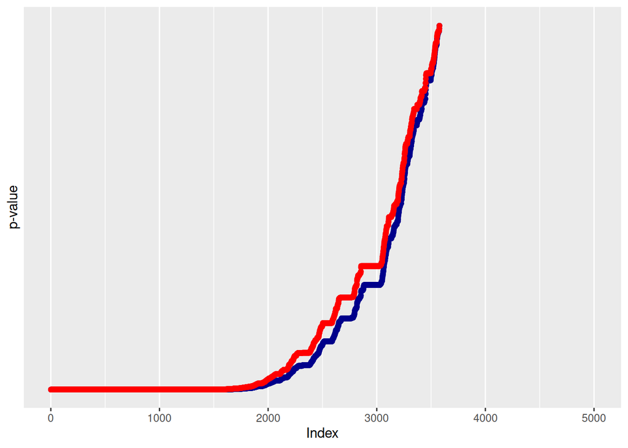

```r
ggplot(result, aes(x=as.numeric(rownames(result)), y = pval)) + xlab("Index") + ylab("p-value") + geom_point(y=result$pval, color="darkblue") + geom_point(y=result$adjusted_pval, color="red") + theme(
  legend.position=c(.95, .95),
  legend.justification=c("right", "top"),
  legend.box.just = "right"
)
```

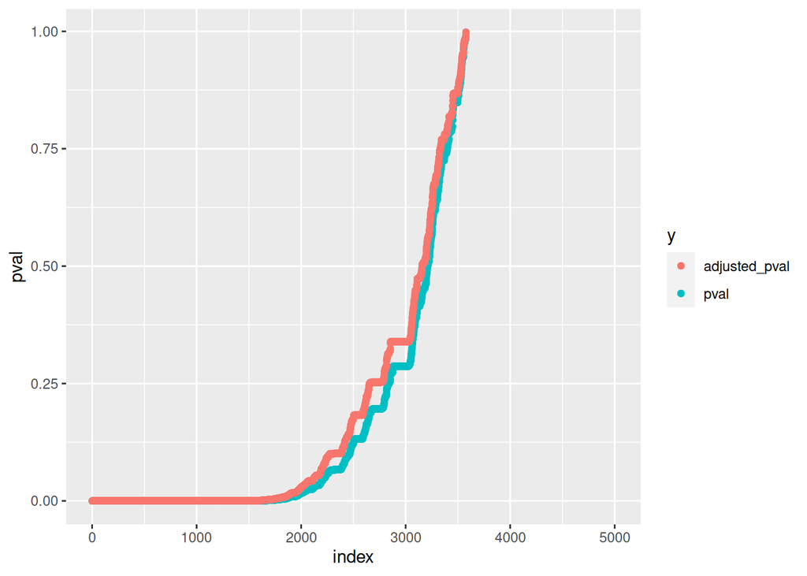

```r
ggplot(result, aes(x=as.numeric(rownames(result)), y = c("pval", "adjusted_pval"), color = y)) + xlab("index") + ylab("pval") + geom_point(aes(y=result$pval, col= "pval")) + geom_point(aes(y=result$adjusted_pval, col="adjusted_pval"))
```

You don’t need `theme()` for making the legend if you use above code accordingly.

### Heatmap

Here we will use a red/yellow palette where red indicates downregulated and yellow indicates upregulated.

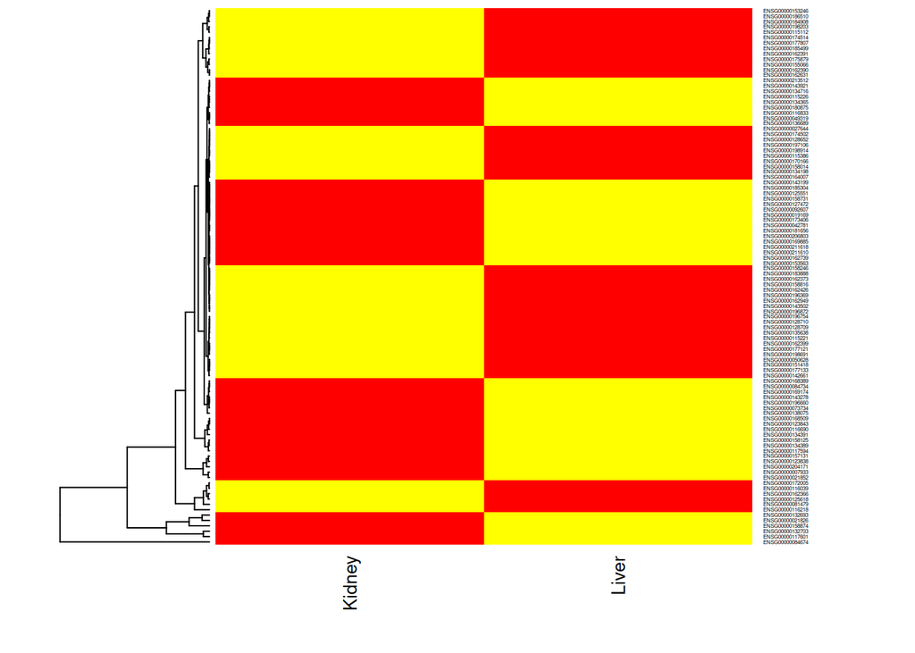

```r
result_sig_up_kidney_sorted <- result_sig_up_kidney[order(-result_sig_up_kidney$log2_Fold_change_normalized),]
result_sig_down_kidney_sorted <- result_sig_down_kidney[order(result_sig_down_kidney$log2_Fold_change_normalized),]

result_top100 <- rbind ( result_sig_up_kidney_sorted[1:50,], result_sig_down_kidney_sorted[1:50,]) # combines vector, matrix, or data frame by rows

cols <- colorRampPalette(c("red","white","yellow"))(256)

heatmap(as.matrix(result_top100[,c(2,3)]), cexRow=0.3, cexCol=1, labRow=result_top100$GeneNames, keep.dendro = F, Colv=NA, labCol=c("Kidney", "Liver"), col=cols)
```

```r
geneExpFile <- system.file("extdata", "GeneExpExample5000.txt", package="DEGseq")
geneExpMat<-read.table(file=geneExpFile,header = T,sep = "\t",na.strings="")
colnames(geneExpMat)<-c("EnsemblGeneID", "Chr", "GeneStart", "GeneEnd", "Status",   "ExternalID", "KidneyR1L1","LiverR1L2","KidneyR1L3", "LiverR1L4", "LiverR1L6", "KidneyR1L7", "LiverR1L8", "LiverR2L1", "KidneyR2L2", "LiverR2L3","KidneyR2L4", "KidneyR2L6", "LiverR2L7", "KidneyR2L8")
```

Now can we pull out the data for those 100 selected genes from this file? Can we make a heatmap for these 100 genes plotting all 14 samples? Use the same colour palette for it and this time we also want a dendogram for x-axis.

[figure not shown]

Why the colors are different here?

```r
gene.exp.matrix1 <- cbind(geneExpMat$EnsemblGeneID, geneExpMat[,c(7, 9, 12, 15, 17, 18, 20)])
gene.exp.matrix2 <- cbind(geneExpMat$EnsemblGeneID, geneExpMat[, c(8, 10, 11, 14, 13, 16, 19)])
```

```r
outputDir <- file.path(getwd(), "fourteen_samples_DEG_analysis")
```

```r
layout(matrix(c(1,2,3,4,5,6), 3, 2, byrow=TRUE))
par(mar=c(2,2,2,2))
DEGexp(geneExpMatrix1 = gene.exp.matrix1, geneCol1=1, expCol1=c(2, 3, 4, 5, 6, 7, 8), groupLabel1="kidney", geneExpMatrix2 = gene.exp.matrix2, geneCol2=1, expCol2=c(2,3,4,5,6,7,8), groupLabel2="liver", method="MARS", outputDir = outputDir)
```

```
## Please wait...
## gene id column in geneExpMatrix1 for sample1:  1
## expression value column(s) in geneExpMatrix1: 2 3 4 5 6 7 8
## total number of reads uniquely mapped to genome obtained from sample1: 345504 354981 334557 366041 308442 372895 298182
## gene id column in geneExpMatrix2 for sample2:  1
## expression value column(s) in geneExpMatrix2: 2 3 4 5 6 7 8
## total number of reads uniquely mapped to genome obtained from sample2: 274430 274486 264999 225966 255041 284205 240970
##
## method to identify differentially expressed genes:  MARS
## pValue threshold: 0.001
## output directory: /home/seungho/GDA/RNAPreprocess/fourteen_samples_DEG_analysis
##
## Please wait ...
```

```
## Identifying differentially expressed genes ...
## Please wait patiently ...
```

```
## output ...
##
## Done ...
## The results can be observed in directory:  /home/seungho/GDA/RNAPreprocess/fourteen_samples_DEG_analysis
```

```r
result_fourteen_samples <- read.table(file=file.path(outputDir, "output_score.txt"), header = T, sep = "\t")
```

```r
head(result_fourteen_samples, 5)
```

```
##         GeneNames value1 value2 log2.Fold_change. log2.Fold_change..normalized
## 1 ENSG00000084674    743  60585         -6.349455                    -6.736766
## 2 ENSG00000143153  56433   2387          4.563269                     4.175957
## 3 ENSG00000163399  49952   1799          4.795275                     4.407964
## 4 ENSG00000158874    371  34280         -6.529804                    -6.917115
## 5 ENSG00000132693    266  28175         -6.726846                    -7.114157
##     z.score p.value q.value.Benjamini.et.al..1995. q.value.Storey.et.al..2003.
## 1 -272.1146       0                              0                           0
## 2  222.1148       0                              0                           0
## 3  211.7806       0                              0                           0
## 4 -203.5457       0                              0                           0
## 5 -183.3819       0                              0                           0
##   Signature.p.value...0.001.
## 1                       TRUE
## 2                       TRUE
## 3                       TRUE
## 4                       TRUE
## 5                       TRUE
```

```r
colnames(result_fourteen_samples) <- c("GeneNames", "value1", "value2", "log2_Fold_change", "log2_Fold_change_normalized", "z_score", "pval", "qval1", "qval2", "Signature")
```

```r
result_14_sig_up_kidney <- result_fourteen_samples[which(result_fourteen_samples$Signature=="TRUE" & result_fourteen_samples$log2_Fold_change_normalized > 0), ]
result_14_sig_down_kidney <- result_fourteen_samples[which(result_fourteen_samples$Signature=="TRUE" & result_fourteen_samples$log2_Fold_change_normalized < 0), ]
```

```r
result_14_sig_up_kidney_sorted <- result_14_sig_up_kidney[order(-result_14_sig_up_kidney$log2_Fold_change_normalized),]
result_14_sig_down_kidney_sorted <- result_14_sig_down_kidney[order(result_14_sig_down_kidney$log2_Fold_change_normalized),]
```

```r
result_14_top100 <- rbind (result_14_sig_up_kidney_sorted[1:50,], result_14_sig_down_kidney_sorted[1:50,])

# combines vector, matrix, or data frame by rows.
```

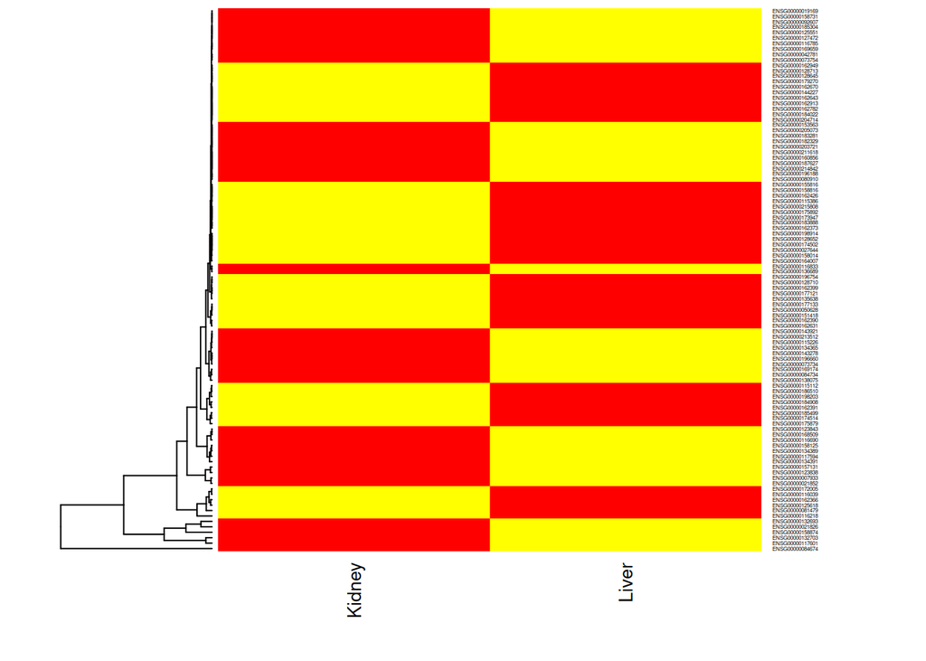

```r
cols <- colorRampPalette(c("red", "white", "yellow"))(256)
heatmap(as.matrix(result_14_top100[,c(2,3)]), cexRow=0.3, cexCol=1, labRow=result_14_top100$GeneNames, keep.dendro = T, Colv=NA, labCol=c("Kidney", "Liver"), col=cols)
```

This isn’t what I need. I need column labels that go by kidney~~ and liver~~.

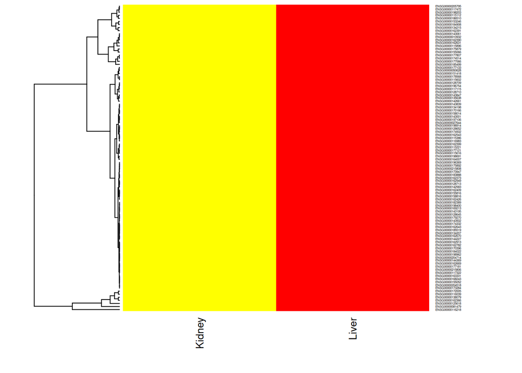

```r
heatmap(as.matrix(result_14_sig_up_kidney_sorted[1:100,c(2,3)]), cexRow=0.3, cexCol=1, labRow=result_14_sig_up_kidney_sorted[1:100,]$GeneNames, keep.dendro=F, Colv=NA, labCol=c("Kidney", "Liver"), col=cols)
```

I don’t know. This is a hard problem.

[^1]: When a model is parsimonious, it means that the model is simple and very efficient at explaining something.
[^2]: For full description, refer to this article called [“DEGseq: an R package for identifying differentially expressed genes from RNA-seq data”](https://academic.oup.com/bioinformatics/article/26/1/136/182236)(A) An example of the summary report page generated by DEGseq. (B) The plot generated by DEGseq showing whether the variation between technical replicates can be largely explained by the random sampling model. The red lines correspond to the ‘theoretical’ 4-fold local SD of M conditioned on A according to the random sampling model calculated by the method described in Section 2.1, and the blue lines show the 4-fold local SD of M estimated by the comparison of technical replicates (as described in Section 2.2). See Supplementary Methods Section 3 for detail. (C) An example of differentially expressed genes (red points) identified between kidney and liver by the MA-plot-based method with random sampling model at an FDR of 0.1%. The red lines show the ‘theoretical’ 4-fold local SD of M according to the random sampling model. (D) An example of differentially expressed genes (red points) identified between kidney and liver by MA-plot-based method with technical replicates at an FDR of 0.1%. Blue points are from the replicates (kidneyR1L1 and kidneyR1L3), and the blue lines show the 4-fold local SD of M for the two technical replicates. (A) An example of the summary report page generated by DEGseq. (B) The plot generated by DEGseq showing whether the variation between technical replicates can be largely explained by the random sampling model. The red lines correspond to the ‘theoretical’ 4-fold local SD of M conditioned on A according to the random sampling model calculated by the method described in Section 2.1, and the blue lines show the 4-fold local SD of M estimated by the comparison of technical replicates (as described in Section 2.2). See Supplementary Methods Section 3 for detail. (C) An example of differentially expressed genes (red points) identified between kidney and liver by the MA-plot-based method with random sampling model at an FDR of 0.1%. The red lines show the ‘theoretical’ 4-fold local SD of M according to the random sampling model. (D) An example of differentially expressed genes (red points) identified between kidney and liver by MA-plot-based method with technical replicates at an FDR of 0.1%. Blue points are from the replicates (kidneyR1L1 and kidneyR1L3), and the blue lines show the 4-fold local SD of M for the two technical replicates.